# Decontamination benchmarking

Author

Christoph

Published

February 27, 2024

# 1. Preparation

## 1.1 Libraries

```r
library(phyloseq)
library (data.table) #fast reading (z.B. fread)
library(ggrepel)
library(SCRuB)
library(PERFect)
library(tidyverse)
library(kableExtra)
library(yingtools2)
library(vegan)
library(openxlsx)
library(microbiome)
library(rstatix)
library(ggpubr)
library(gridExtra)
library(grid)
library(decontam)
# library(cluster)
library(pairwiseAdonis)
library(VennDiagram)
```

## 1.2 Functions

```r
## adding functions
Path2Function <- "../../../functions/"
source(paste0(Path2Function,"MyFunctionsV2.R"))
source(paste0(Path2Function,"MyAnalysisWithPlots.R"))

cols <- c("#9d547c","#56ca63","#a357d6","cornflowerblue","#419d2a","sandybrown","red3","peachpuff","cyan","paleturquoise3","mistyrose","mediumpurple","mediumseagreen","mediumorchid","moccasin","orange4","olivedrab","midnightblue","papayawhip","palevioletred4","brown1","greenyellow","orchid","navy","darkred","navajowhite1","mistyrose1","grey85","#525fd6","red2","#8cbe3a","#c944aa","indianred3","#5ba557","#9e66cb","#c1b735","#6d82ec","grey25","#e69728","#6654b0","lightsalmon3","lightcyan1","khaki1","seagreen1","plum1","lightsteelblue1","palevioletred3","mintcream","magenta3","#799330","#da7fdf","#3c782c","#e44586","blue4","#63c996","#dc3f53","#49cbc8","#cf3f29","#4fabda","#da6c2b","#598bd1","#b78c24","#8d4191","#a0b971","slategray1","sienna","plum1","lightyellow1","lightskyblue3","linen","limegreen","cornsilk1","mediumaquamarine","gray14","gold3","darkviolet","#b2386a","#479d71","#ae4341","#2ba198","#e07557","#5361a3","#dda353","#aa98df","#5b6114","#dc89bf","#327243","slateblue1","#e57b94","#277257","#9b62a0","#bbab59","#98495a","#526229","#d8827d","#857624","gray40","#9a4a22","#7c7d46","mediumslateblue","lemonchiffon1","#e3a073","#9e6b33", "gray74","slateblue1","rosybrown3", "lawngreen","gainsboro","dodgerblue3","deeppink3","firebrick3", "orchid2", "olivedrab1", "ivory3", "darkseagreen", "bisque2", "darkgoldenrod2", "blue2", "skyblue", "seashell2", "turquoise", "tan1", "seagreen2", "palevioletred3", "linen", "steelblue4","ghostwhite","dodgerblue1","deeppink1","firebrick1", "limegreen", "purple3", "khaki3", "snow3", "darkslategray","darkorchid","lavender", "magenta2", "palegreen", "salmon", "maroon", "cyan2","#671408","#FAEBD7","#7FFFD4","#F0FFFF","#A52A2A","burlywood","cadetblue","#7FFF00","chocolate","cornsilk","slateblue1","#FF7F50","red1","#008B8B","darkgoldenrod1","darkolivegreen","darkorange4","white","hotpink","honeydew1","goldenrod2","darkgreen","oldlace","darkslategray3","navajowhite3","orchid4","gray25","#F0924D")
```

## 1.3 Loading samples

### 1.3.1 True samples

```r
physeq1 <- readRDS("physeqs/physeq_1750_90_q15.rds")
#no reason to merge any phyloseq objects as only 1 phyloseq object exists
p.true.original <- physeq1
#clean objects
rm(list = c("physeq1"))
ntaxa.true.raw <- nrow(otu_table(p.true.original)) #This line calculates the number of taxa present in p.true.phyloseq by first converting the phyloseq object into an otu table and then counting the rows in that table using nrow function.
zero_true_raw <- sum(otu_table(p.true.original) == 0)/nrow(meta(p.true.original))
#it calculates the proportion of samples with zero read counts for each taxa in p.true. original.
```

Now in true samples, we have: *8* samples and *302* taxa

### 1.3.2 NCT

```r
physeq.nct1 <- readRDS("physeqs/physeq_1000_50_nct.rds")
physeq.nct2 <- readRDS("physeqs/physeq_acid_nct.rds")
#no reason to merge any phyloseq objects as only 1 phyloseq object exists
physeq.nct.original <- merge_phyloseq(physeq.nct1, physeq.nct2)
#clean objects
rm(list = c('physeq.nct1'))
ntaxa.nct.raw <- nrow(otu_table(physeq.nct.original))
zero_nct_raw <- sum(otu_table(physeq.nct.original) == 0)/nrow(meta(physeq.nct.original))

overlap.raw <- length(
  which(
    !is.na(
      match(
        rownames(otu_table(physeq.nct.original)),
        rownames(otu_table(p.true.original))
      )
    )
  )
)
```

Now in NCT samples, we have: *8* samples and *661* taxa

## 1.4 Batch data

We create the batch data from the assumptions:

```r
p.true.original@sam_data$Treatment <- c("ctrl","ctrl","ctrl","ctrl","Gem","Gem","Gem","Gem")
p.true.original@sam_data$TRUE_control <- rep("TRUE",nsamples(p.true.original))
p.true.original@sam_data$is.neg <- sample_data(p.true.original)$TRUE_control == "control"


physeq.nct.original @sam_data$sample_side <- c("buffer","buffer","pcr","sequence", "buffer","buffer","pcr","sequence")
physeq.nct.original @sam_data$TRUE_control <- rep("control",nsamples(physeq.nct.original ))
physeq.nct.original @sam_data$is.neg <- sample_data(physeq.nct.original )$TRUE_control == "control"


#Now assign the batch numbers
#DNAex_round
p.true.original@sam_data$DNAex_round <- rep(1,nsamples(p.true.original))
physeq.nct.original @sam_data$DNAex_round <- c(1,1,NA,NA,1,1,NA,NA)
#PCR_round
p.true.original@sam_data$PCR_round <- rep(1,nsamples(p.true.original))
physeq.nct.original @sam_data$PCR_round <- c(1,1,1,NA,1,1,1,NA)
#Seq_round
p.true.original@sam_data$Seq_round <- rep(1,nsamples(p.true.original))
physeq.nct.original @sam_data$Seq_round <- c(1,1,1,1,1,1,1,1)
```

Now in true sample, we have *8* samples and *302* taxa. In the NCTs, we have *8* samples and *661* taxa.

# 2 Preprocessing

## 2.1 Filterung, Agglomarting

We keep only bacterial reads with resolution to species

```r
## for true samples
p.true.filt <- subset_taxa(p.true.original, superkingdom=="Bacteria")
p.true.filt.s <- tax_glom(p.true.filt, taxrank = "species", NArm = TRUE)

rm(p.true.filt)
## for NCTs
physeq.nct.filt <- subset_taxa(physeq.nct.original, superkingdom=="Bacteria")
physeq.nct.filt.s <- tax_glom(physeq.nct.filt, taxrank = "species", NArm = TRUE)

rm(physeq.nct.filt)
```

## 2.2 Sequencing depth

### 2.2.1 True samples - Sequencing depth

Before using tissue data for further downstream analysis, we firstly need to apply QC (quality control). We remove samples from our tissue set whose read counts are below a given threshold. The respective read counts are too low and do not yield confident presence/absence calls.

```r
Inspect_SequencingDepth(PhyloObj = p.true.filt.s)
```

Bacterial reads

| value | id |
| --- | --- |
| 87144 | gem_6026 |
| 91384 | gem_6037 |
| 92997 | gem_6031 |
| 100533 | ctrl_5974 |
| 105339 | ctrl_5976 |
| 115877 | ctrl_5975 |
| 121330 | gem_6036 |
| 134232 | ctrl_5984 |

```r
visualize_samples_low_reads(p.true.filt.s,type = "Tissue")
```

Tissue read counts

| >150 reads | >250 reads | >500 reads | >750 reads | >1000 reads |
| --- | --- | --- | --- | --- |
| 8 | 8 | 8 | 8 | 8 |

```r
seq_depth.true <- data.frame(id = meta(p.true.filt.s)$id,
                 barcode = meta(p.true.filt.s)$barcode,
                 nreads = sample_sums(p.true.filt.s),
                 log2_reads = log2(sample_sums(p.true.filt.s)),
                 log10_reads = log10(sample_sums(p.true.filt.s)))
```

### 2.2.2 NCTs - Sequencing depth

```r
Inspect_SequencingDepth(physeq.nct.filt.s)
```

Bacterial reads

| value | id |
| --- | --- |
| 47 | NCT_gem_Seq_TT_16S |
| 61 | NCT_acid_Seq_TT_16S |
| 12061 | NCT_acid_PCR_TT_16S |
| 12616 | NCT_2_acid_Ext_TT_16S |
| 12737 | NCT_1_acid_Ext_TT_16S |
| 17045 | NCT_gem_PCR_TT_16S |
| 18443 | NCT_1_gem_Ext_TT_16S |
| 21458 | NCT_2_gem_Ext_TT_16S |

```r
visualize_samples_low_reads(physeq.nct.filt.s,type = "NTC")
```

NTC read counts

| >150 reads | >250 reads | >500 reads | >750 reads | >1000 reads |
| --- | --- | --- | --- | --- |
| 6 | 6 | 6 | 6 | 6 |

```r
seq_depth.nct <- data.frame(id = meta(physeq.nct.filt.s)$id,
                 barcode = meta(physeq.nct.filt.s)$barcode,
                 nreads = sample_sums(physeq.nct.filt.s),
                 log2_reads = log2(sample_sums(physeq.nct.filt.s)),
                 log10_reads = log10(sample_sums(physeq.nct.filt.s)))
```

Now, in NTC samples, we have *8* samples and *525* taxa.

### 2.2.3 Excluding samples with low seq depth

```r
bac.count_cut_off_true <- 5000
bac.count_cut_off_nct <- 40
```

We decide to remove Tissue samples if their read counts are less than **5000 reads/sample** and NCT with a read count less than **40 reads/sample**

#### 2.2.3.1 True samples

```r
bac.count <- tibble(bac.count = sample_sums(p.true.filt.s),
                          sample = sample_data(p.true.filt.s)$id)
id.ex <- bac.count %>% filter(bac.count < bac.count_cut_off_true) %>% pull (sample)
physeq.read.filt <- subset_samples(p.true.filt.s, !(id %in% id.ex))
physeq.read.filt <- prune_taxa(taxa_sums(physeq.read.filt)>0, physeq.read.filt)
p.true.filt.s <- physeq.read.filt
rm(bac.count)
rm(id.ex)
rm(physeq.read.filt)
```

Now, in Tissue samples, we have *8* samples and *185* taxa.

#### 2.2.3.2 NCT

```r
bac.count <- tibble(bac.count = sample_sums(physeq.nct.filt.s),
                          sample = sample_data(physeq.nct.filt.s)$id)
id.ex <- bac.count %>% filter(bac.count < bac.count_cut_off_nct) %>% pull (sample)
physeq.read.filt <- subset_samples(physeq.nct.filt.s, !(id %in% id.ex))
physeq.read.filt <- prune_taxa(taxa_sums(physeq.read.filt)>0, physeq.read.filt)
physeq.nct.filt.s <- physeq.read.filt
rm(bac.count)
rm(id.ex)
rm(physeq.read.filt)
```

## 2.3 Unification of taxids

We have 2 phyloseq objects that may describe the same species using different OTU handles. We therefore unify the OTU handles for an easier downstream analysis.

### 2.3.1 - Merging true samples and negative controls

```r
p.comb.filt <- merge_phyloseq(p.true.filt.s,physeq.nct.filt.s)
p.comb.filt.s <- tax_glom(p.comb.filt,taxrank = "species", NArm = TRUE)
rm(p.comb.filt)
```

### 2.3.2 - Demerging true samples and negative controls samples

-it refers to the process of separating the merged data set into two distinct data set: one containing only the true samples and the other containing only the negative control samples

```r
p.true.filt.s.unify <- subset_samples(p.comb.filt.s,TRUE_control=="TRUE") #only true samples
p.true.filt.s.unify <- prune_taxa(x = p.true.filt.s.unify,taxa = taxa_names(p.true.filt.s.unify)[-(which(taxa_sums(p.true.filt.s.unify)==0))]) #only taxa found in true samples

physeq.nct.filt.s.unify <- subset_samples(p.comb.filt.s,TRUE_control == "control") #only NCT samples
physeq.nct.filt.s.unify <- prune_taxa(x = physeq.nct.filt.s.unify,taxa = taxa_names(physeq.nct.filt.s.unify)[-(which(taxa_sums(physeq.nct.filt.s.unify)==0))]) #only taxa found in NCT samples
```

## 2.4 - Prevalence filtering

```r
p.true.RmLowAbun <- filter_by_low_abundance(phyloseqObj = p.true.filt.s.unify,threshold =0.00001 ,A = 1)


physeq.nct.RmLowAbun <- filter_by_low_abundance(phyloseqObj = physeq.nct.filt.s.unify,threshold =0.00001 ,A = 1)
```

Now we have *8* samples and *166* taxa in the true sample set and *8* samples and *525* taxa in the NCT sample set.

First of all, let us check the taxa overlap between NCT samples and true sample after low-abundance filtering by rule of thumb.

### 2.4.1 Venn Diagram

[output not shown]

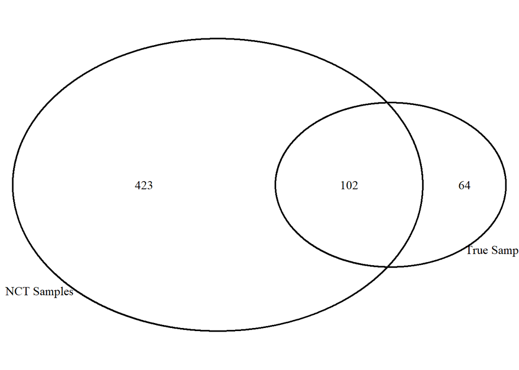

```r
PlotVenn2Sets(taxa_names(p.true.RmLowAbun) %>% unique(),
              taxa_names(physeq.nct.RmLowAbun) %>% unique(),
              "True Samples" , "NCT Samples ")
```

There are 423 taxa belong to NCT samples but not in true samples (after rule of thumb).

### 2.4.2 Microbial composition

#### 2.4.2.1 True samples

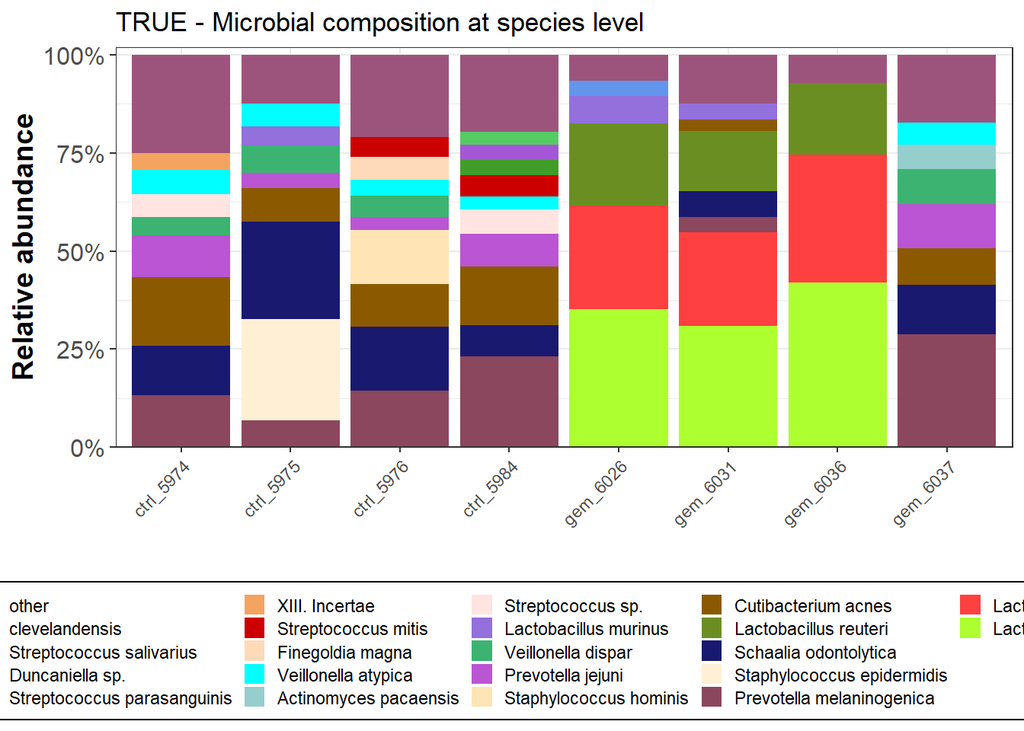

```r
p.prop <- microbiome::transform(p.true.RmLowAbun, "compositional")
df.fam.melt <- psmelt(p.prop) %>%
  mutate(species.v2 = if_else(
    Abundance < 0.03, "other", species
   ),
   species.v2 = factor(species.v2, levels=rev(unique(species.v2)))
  )

rm(p.prop)


#microbial composition at species level
ggplot(df.fam.melt, aes(x=id, y=Abundance, fill=species.v2)) +
  geom_bar(stat="identity") +
  scale_y_continuous(labels = scales::percent, expand = c(0, 0), limits = c(0, 1.02)) +
  scale_fill_manual(values = cols) +
  xlab ("") +
  ylab("Relative abundance") +
  theme_bw() +
  # facet_wrap(vars(Treatment), scales = "free_y") +
  ggtitle("TRUE - Microbial composition at species level")+
  # facet_wrap(~sample_side, scales = "free")+
  theme( axis.text.x = element_text(angle = 45,hjust=1),
        axis.text.y = element_text (size=12),
        axis.title = element_text(size=14, face="bold"))+
  theme(legend.position = "bottom",
        legend.title = element_blank(),
        legend.background = element_rect(linetype="solid", colour ="black"),
        legend.key.size = unit(4,"mm"))
```

### 2.4.2.2 NCTs

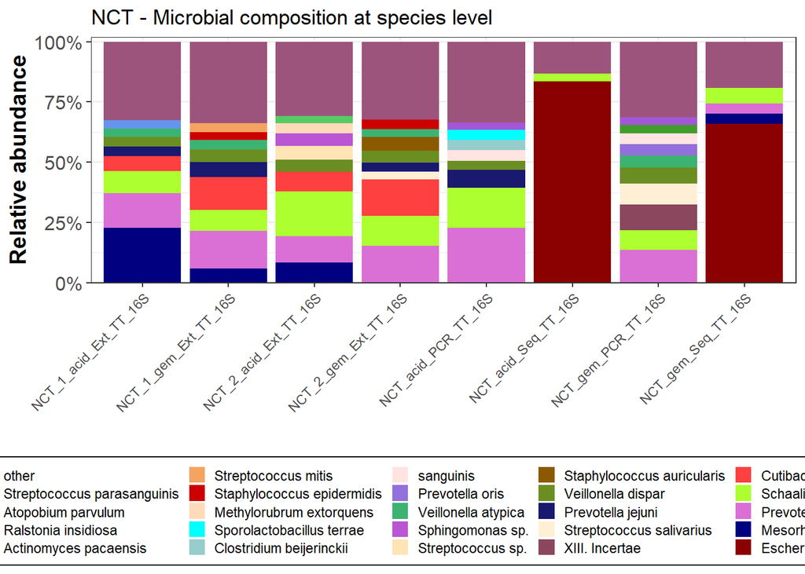

```r
nct.prop <- microbiome::transform(physeq.nct.RmLowAbun, "compositional")
df.nct.melt <- psmelt(nct.prop) %>%
  mutate(species.v2 = if_else(
    Abundance < 0.03, "other", species
   ),
   species.v2 = factor(species.v2, levels=rev(unique(species.v2)))
  )

rm(nct.prop)


ggplot(df.nct.melt, aes(x=id, y=Abundance, fill=species.v2)) +
  geom_bar(stat="identity") +
  scale_y_continuous(labels = scales::percent, expand = c(0, 0), limits = c(0, 1.02)) +
  scale_fill_manual(values = cols) +
  xlab ("") +
  ylab("Relative abundance") +
  theme_bw() +
  # facet_wrap(vars(Treatment), scales = "free_y") +
  ggtitle("NCT - Microbial composition at species level")+
  # facet_wrap(~sample_side, scales = "free")+
  theme( axis.text.x = element_text(angle = 45,hjust=1),
        axis.text.y = element_text (size=12),
        axis.title = element_text(size=14, face="bold"))+
  theme(legend.position = "bottom",
        legend.title = element_blank(),
        legend.background = element_rect(linetype="solid", colour ="black"),
        legend.key.size = unit(4,"mm"))
```

## 2.6. Decontamination

Here we evaluate different deconatmination tools.

1. Decontam
2. SCRuB
3. Nejman et al.

As indicators for sufficient decontamination following parameter are examined:  
1. Count of species remaining the true samples  
2. Count of species identified as contaminants  
3. Comparison decontaminating samples with a database of common contaminants

### 2.6.1 Preparation

Merging of both

```r
p.comb.RmLowAbun <- merge_phyloseq(p.true.RmLowAbun, physeq.nct.RmLowAbun)
```

### 2.6.2 Decontam

#### 2.6.2.1 Applying function

We apply decontam by using isContaminant function with the prevalence option.

```r
threshold <- 0.8
contamdf.prev <- isContaminant(p.comb.RmLowAbun, method="prevalence", neg="is.neg", threshold = threshold, normalize = FALSE)
cont <- as.data.frame(table(contamdf.prev$contaminant))
which(contamdf.prev$contaminant)
```

```
  [1]   1   2  13  14  15  16  17  18  20  21  23  29  34  37  38  39  40  41
 [19]  42  43  44  45  47  50  53  55  57  62  67  69  71  72  73  74  76  77
 [37]  82  85  86  89  93  94  95  97  98  99 101 102 103 105 106 107 108 109
 [55] 124 133 136 138 139 140 141 146 147 149 150 153 154 155 158 159 160 163
 [73] 164 165 166 168 169 170 171 173 174 175 176 178 181 182 183 184 185 186
 [91] 187 188 189 192 193 194 195 196 198 201 203 204 206 208 209 210 212 213
[109] 214 215 216 219 221 222 224 226 230 234 235 240 243 244 245 248 253 260
[127] 263 266 270 272 274 276 277 278 279 283 284 286 287 288 292 295 296 298
[145] 299 303 305 308 309 310 311 312 317 318 321 325 329 331 332 336 337 338
[163] 343 345 346 348 350 352 354 355 356 363 366 368 369 370 371 373 374 379
[181] 380 381 382 384 385 390 394 395 396 398 407 408 409 411 414 417 453 462
[199] 463 468 491 522 528 534 539 544 545 555 557 560
```

```r
ncont_decontam <- cont[2,2]
```

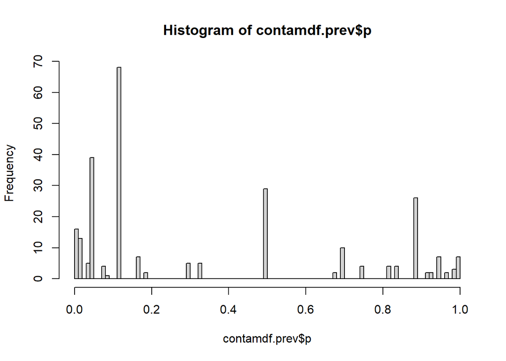

```r
hist(contamdf.prev$p, 100)
```

We will control the defined contaminants by looking to the distribution of contaminated taxa within true and control samples.

#### 2.6.2.2 Control plot

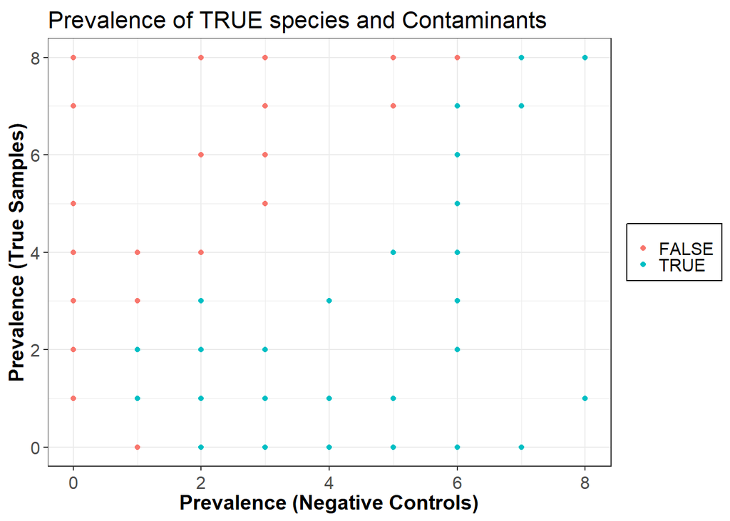

```r
# Make phyloseq object of presence-absence in negative controls and true samples
ps.pa <- transform_sample_counts(p.comb.RmLowAbun, function(abund) 1*(abund>0))
ps.pa.neg <- prune_samples(sample_data(ps.pa)$TRUE_control == "control", ps.pa)
ps.pa.pos <- prune_samples(sample_data(ps.pa)$TRUE_control == "TRUE", ps.pa)
# Make data.frame of prevalence in positive and negative samples
df.pa <- data.frame(pa.pos=taxa_sums(ps.pa.pos), pa.neg=taxa_sums(ps.pa.neg),
                      contaminant=contamdf.prev$contaminant)
ggplot(data=df.pa, aes(x=pa.neg, y=pa.pos, color=contaminant)) + geom_point() +
  xlab("Prevalence (Negative Controls)") + ylab("Prevalence (True Samples)") + ggtitle("Prevalence of TRUE species and Contaminants") + theme_bw()+
  theme(axis.text.x = element_text(size=12, hjust = .5, vjust = .5),
        axis.text.y = element_text (size=12),
        axis.title = element_text(size=14, face="bold"),
        legend.text = element_text(size = 12),
        legend.title = element_blank(),
        plot.title = element_text(size = 16, vjust = 0.5),
        legend.background = element_rect(linetype="solid", colour ="black"),
        legend.key.size = unit(4,"mm"))
```

#### 2.6.2.3 Removing contaminants

We further remove species that are defined as contaminants and subsample the negative controls.

```r
p.comb.RmLowAbun_dcdefault <- prune_taxa(!contamdf.prev$contaminant, p.comb.RmLowAbun)
p.RmLowAbun_dcdefault <- subset_samples(p.comb.RmLowAbun_dcdefault, is.neg ==FALSE)
p.RmLowAbun_dcdefault <- prune_taxa(x = p.RmLowAbun_dcdefault, taxa = taxa_names(p.RmLowAbun_dcdefault)[-(which(taxa_sums(p.RmLowAbun_dcdefault)==0))])

saveRDS(p.RmLowAbun_dcdefault,"physeqs/p.decontam_8nct.rds")
```

#### 2.6.2.4 Microbial composition

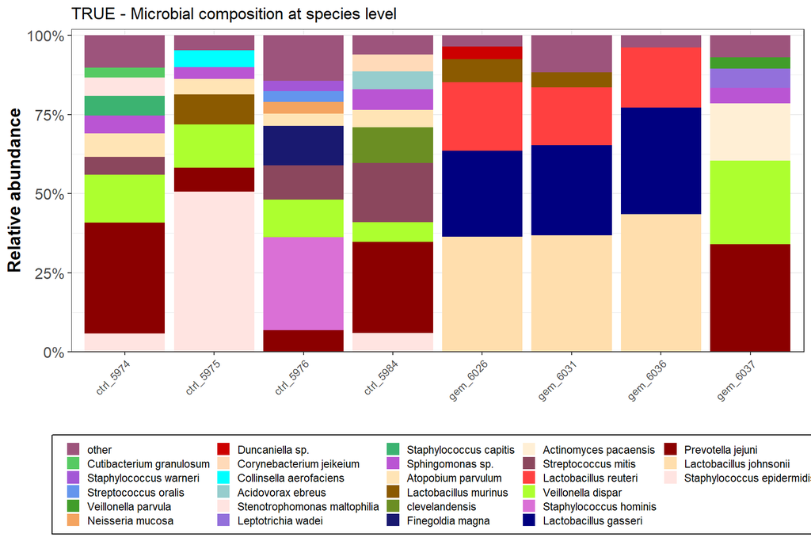

```r
p.prop <- microbiome::transform(p.RmLowAbun_dcdefault, "compositional")
df.fam.melt <- psmelt(p.prop) %>%
  mutate(species.v2 = if_else(
    Abundance < 0.03, "other", species
   ),
   species.v2 = factor(species.v2, levels=rev(unique(species.v2)))
  )

rm(p.prop)


#microbial composition at species level
ggplot(df.fam.melt, aes(x=id, y=Abundance, fill=species.v2)) +
  geom_bar(stat="identity") +
  scale_y_continuous(labels = scales::percent, expand = c(0, 0), limits = c(0, 1.02)) +
  scale_fill_manual(values = cols) +
  xlab ("") +
  ylab("Relative abundance") +
  theme_bw() +
  # facet_wrap(vars(Treatment), scales = "free_y") +
  ggtitle("TRUE - Microbial composition at species level")+
  # facet_wrap(~sample_side, scales = "free")+
  theme( axis.text.x = element_text(angle = 45,hjust=1),
        axis.text.y = element_text (size=12),
        axis.title = element_text(size=14, face="bold"))+
  theme(legend.position = "bottom",
        legend.title = element_blank(),
        legend.background = element_rect(linetype="solid", colour ="black"),
        legend.key.size = unit(4,"mm"))
```

### 2.6.3 SCRUB

SCRuB was introduced 2023 and published by Austin et al. in Nature Biotechnologies [publication](https://www.nature.com/articles/s41587-023-01696-w). A tutorial is found in [github](https://github.com/Shenhav-and-Korem-labs/SCRuB?tab=readme-ov-file).

According to the github the out_table needs to be transposed. The metadata should only contain 2 columns (is_control, sample_type). A control order can be facultatively be introduced.

With control_order there are 3 more contaminants identified then without with our respective data set.

#### 2.6.3.1 SCRuB Preparation and function

```r
scrub_otu <- as.data.frame(otu_table(p.comb.RmLowAbun)) %>%
  t()

scrub_meta <- meta(p.comb.RmLowAbun) %>%
  select(is.neg, Treatment, sample_side) %>%
  mutate(sample_side = if_else(is.na(sample_side), Treatment, sample_side)) %>%
  rename(is_control = is.neg,
         samüple_type = sample_side) %>%
  select(-Treatment)



scr_out <- SCRuB(scrub_otu,scrub_meta,
        control_order = c("buffer", "pcr", "sequence")
                         )
```

```
[1] "Did not find well metadata, running SCRuB without the spatial component"
[1] "SCRuBbing away contamination in the buffer controls..."
[1] "SCRuBbing away contamination in the pcr controls..."
[1] "SCRuBbing away contamination in the sequence controls..."
```

```r
decont_otu_scr <- as.data.frame(scr_out$decontaminated_samples) %>%
  select(where(~sum(.) != 0)) %>%
  t() %>%
  otu_table(taxa_are_rows = TRUE)
```

#### 2.6.3.2 SCRuB Output

The output is a list of objects. The first element of the output is a ready to use otu_table with deconatimanted true samples. It only needs to be transposed and merged into the phyloseq object.

```r
p.RmLowAbun_scrub <- phyloseq(decont_otu_scr, tax_table(p.comb.RmLowAbun), sample_data(p.true.RmLowAbun))
```

The second element is a vector providing the proportion of contaminants in each sample. 1 means no contamination 0 means all taxa are identified contaminants.

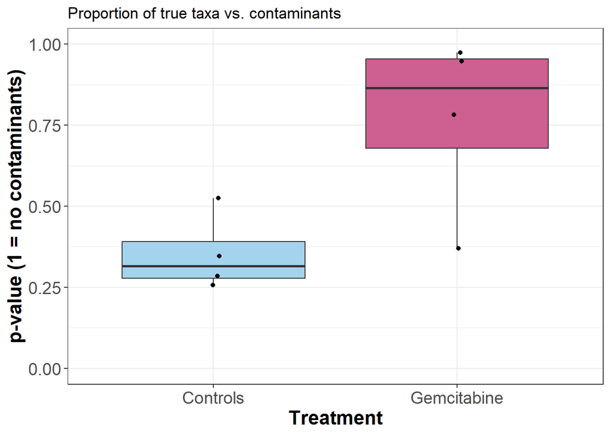

```r
as.data.frame(scr_out$p) %>%
  mutate(samples = rownames(.),
         group = c("ctrl", "ctrl", "ctrl", "ctrl", "gem", "gem", "gem", "gem")) %>%
  ggplot(aes(x=group, y=scr_out$p, fill= group)) +
  # geom_violin()+
  geom_boxplot()+
  geom_point (position=position_jitterdodge( jitter.width = 0.05))+
  theme_bw() +
  ggtitle ("Proportion of true taxa vs. contaminants") +
  scale_x_discrete(labels= c("Controls", "Gemcitabine"))+
  xlab("Treatment")+
  ylab("p-value (1 = no contaminants)")+
  ylim(0,1)+
   scale_fill_manual(values = c("lightskyblue2", "hotpink3"), labels= c("Controls", "Gemcitabine"))+
theme (axis.text=element_text(size=14),
         axis.title=element_text(size=16,face="bold"),
         legend.position =  "none",
         legend.title = element_blank(),
         legend.background = element_rect(linetype="solid", colour ="black"))
```

Finally we store the decontaminated phyloseq.

```r
saveRDS(p.RmLowAbun_scrub,"physeqs/p.scrub_8nct.rds")
```

#### 2.6.3.3 Microbial composition

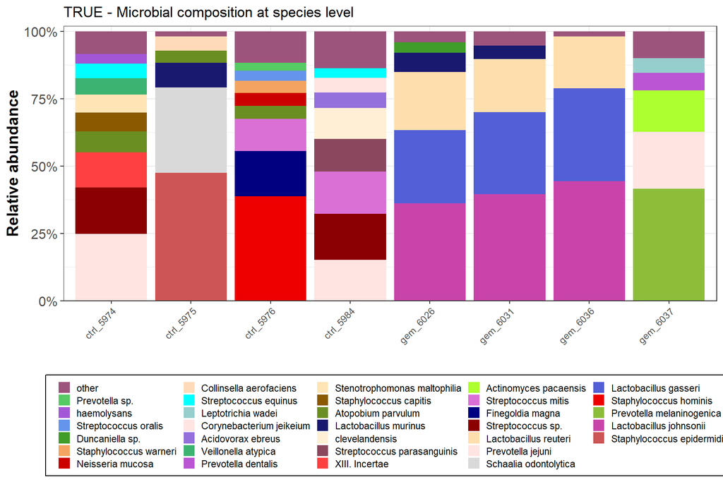

```r
p.prop <- microbiome::transform(p.RmLowAbun_scrub, "compositional")
df.fam.melt <- psmelt(p.prop) %>%
  mutate(species.v2 = if_else(
    Abundance < 0.03, "other", species
   ),
   species.v2 = factor(species.v2, levels=rev(unique(species.v2)))
  )

rm(p.prop)


#microbial composition at species level
ggplot(df.fam.melt, aes(x=id, y=Abundance, fill=species.v2)) +
  geom_bar(stat="identity") +
  scale_y_continuous(labels = scales::percent, expand = c(0, 0), limits = c(0, 1.02)) +
  scale_fill_manual(values = cols) +
  xlab ("") +
  ylab("Relative abundance") +
  theme_bw() +
  # facet_wrap(vars(Treatment), scales = "free_y") +
  ggtitle("TRUE - Microbial composition at species level")+
  # facet_wrap(~sample_side, scales = "free")+
  theme( axis.text.x = element_text(angle = 45,hjust=1),
        axis.text.y = element_text (size=12),
        axis.title = element_text(size=14, face="bold"))+
  theme(legend.position = "bottom",
        legend.title = element_blank(),
        legend.background = element_rect(linetype="solid", colour ="black"),
        legend.key.size = unit(4,"mm"))
```

### 2.6.4 Nejman approach

According to the Nejman et al publication first high abundant contaminants are removed. Secondly low abundant contaminants are addressed.

#### 2.6.4.1 High prevalence taxas in NCTs

##### 2.6.4.1.1 Overview high prevalent contaminants

We consider all taxas whose prevalence in NCTs are higher than a certain threshold (eg. 50%) are contaminants.

This is Filter-1 (General contaminants removal) according to Nejman et al.

In order to determine that threshold, we have a look at the plot below

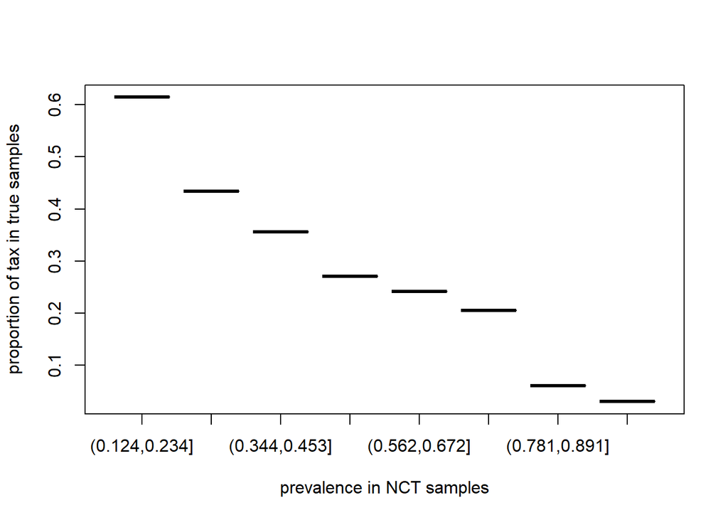

```r
xout <- HighPrevalence_Data(p.true.RmLowAbun, physeq.nct.RmLowAbun)
plot(xout$factorx, xout$rel_tax, xlab="prevalence in NCT samples", ylab="proportion of tax in true samples")
```

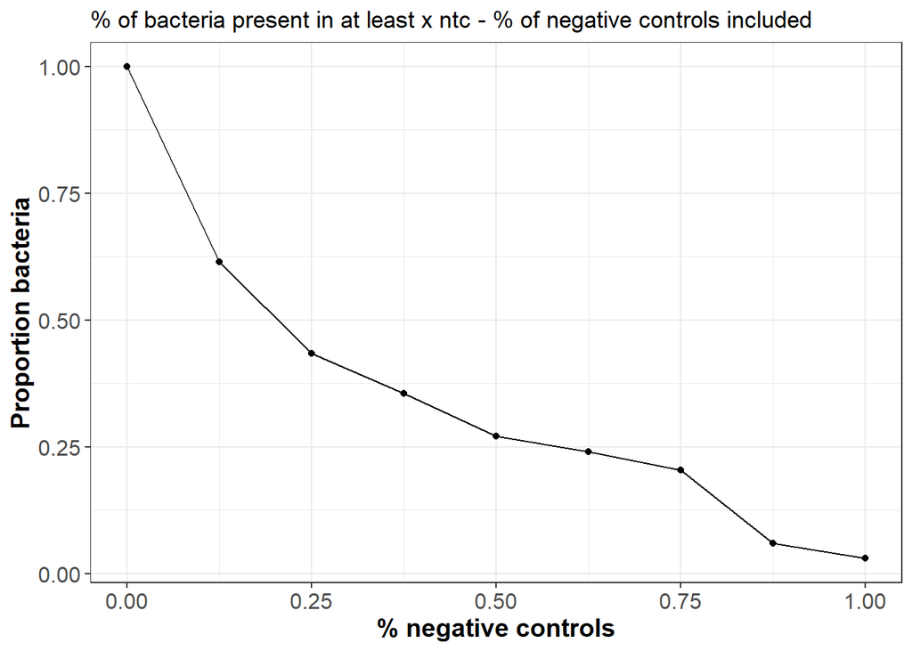

```r
prev_ntc = tibble(
  prev.ntc = prevalence(physeq.nct.RmLowAbun, detection  = 0, sort = TRUE, count = FALSE),
  OTU =as.factor(names(prevalence(physeq.nct.RmLowAbun , detection = 0, sort = TRUE, count = FALSE)))
)

prev_true = tibble(
  prev.true = prevalence(p.true.RmLowAbun, detection  = 0, sort = TRUE, count = FALSE),
  OTU =as.factor(names(prevalence(p.true.RmLowAbun , detection = 0, sort = TRUE, count = FALSE)))
)

prev <- prev_true %>%
  left_join(prev_ntc) %>%
  mutate(prev.ntc = ifelse(is.na(prev.ntc), 0, prev.ntc),
         prev.true = ifelse(is.na(prev.true), 0, prev.true))

prev_count.mod <- prev %>% # rebuild "prev_count" object
  dplyr::count(prev.ntc) %>% # rebuild "prev_count" object
  mutate(prop = n/nrow(prev)) %>% # rebuild "prev_count" object
  arrange(-prev.ntc) %>% #orders the tibble starting with highest prev.ntc value and ending with lowest prev.ntc
  mutate(csum = cumsum(n)) %>% #create column containing the cumulative sum of n
  mutate(cumprop = csum/nrow(prev)) # take the cumsum and divide by the amount of taxa
# Idea behind this:
# In previous plots we used to plot the exact number / proportion of bacteria contained in x% of negative controls yielding nejman.figure.jpg / Graph 1 in notepad.
# Now we plot the proportion of bacteria contained in at least x% of negative controls.
# x = % of negative controls | y = (sum of all bacteria present in more than x negative controls + bacteria present in x negative controls) / (all bacteria)


ggplot(prev_count.mod, aes(x= prev.ntc, y = cumprop))+
  geom_point()+
  xlab ("% negative controls") +
  ylab("Proportion bacteria") +
  theme_bw() +
  geom_line()+
  ggtitle("% of bacteria present in at least x ntc - % of negative controls included")+
  theme( axis.text.x = element_text(size=12),
         axis.text.y = element_text (size=12),
         axis.title = element_text(size=14, face="bold"))+
  theme(legend.position = "bottom",
        legend.title = element_blank(),
        legend.background = element_rect(size=0.25, linetype="solid", colour ="black"),
        legend.key.size = unit(4,"mm"))
```

This plot shows us how many percents of taxa we would remove from true samples (y-axis) if we pick up a threshold for high prevalence in NCT samples (x-axis).

##### 2.6.4.1.2 Define high prevalent contaminants

```r
filter <- 0.75
filtered_taxa1 <- tibble(
  Cont = genefilter_sample(physeq.nct.RmLowAbun, filterfun_sample(function(x) x > 0), A=filter*nsamples(physeq.nct.RmLowAbun)),
  OTU = names(genefilter_sample(physeq.nct.RmLowAbun, filterfun_sample(function(x) x > 0), A=filter*nsamples(physeq.nct.RmLowAbun)))
) %>%
  arrange (-Cont)

cont.count <- filtered_taxa1 %>% dplyr::count(Cont)
cont.count %>%
  kable (caption=paste("Count of contaminants (filter", filter*100, " %)"), booktabs =TRUE) %>%
  kable_classic(full_width = F, html_font = "Cambria") %>%
  kable_styling(bootstrap_options = c("striped", "hover", "condensed", "responsive"))
```

Count of contaminants (filter 75 %)

| Cont | n |
| --- | --- |
| FALSE | 483 |
| TRUE | 42 |

```r
psmelt(physeq.nct.RmLowAbun) %>% select(OTU, species) %>%
  unique %>%
  right_join(filtered_taxa1) %>%
  filter(Cont == TRUE) %>%
  select(-Cont) %>%
  kable (caption=paste("Contaminants (filter", filter*100, " %)"), booktabs =TRUE) %>%
  kable_classic(full_width = F, html_font = "Cambria") %>%
  kable_styling(bootstrap_options = c("striped", "hover", "condensed", "responsive")) %>%
  scroll_box(width = "70%", height = "600px")
```

Contaminants (filter 75 %)

| OTU | species |
| --- | --- |
| 28132 | Prevotella melaninogenica |
| 1747 | Cutibacterium acnes |
| 2725666 | Mesorhizobium sp. |
| 1660 | Schaalia odontolytica |
| 114527 | XIII. Incertae |
| 1304 | Streptococcus salivarius |
| 39778 | Veillonella dispar |
| 1177574 | Prevotella jejuni |
| 39777 | Veillonella atypica |
| 28135 | Prevotella oris |
| 84135 | sanguinis |
| 2610896 | Streptococcus sp. |
| 28037 | Streptococcus mitis |
| 1523415 | Sphingomonas sp. |
| 1852377 | Actinomyces pacaensis |
| 521095 | Atopobium parvulum |
| 653931 | Sphingomonas alpina |
| 760570 | Streptococcus parasanguinis |
| 43675 | Rothia mucilaginosa |
| 28131 | Prevotella intermedia |
| 1458465 | Megasphaera elsdenii |
| 52773 | Schaalia meyeri |
| 2144175 | Megasphaera stantonii |
| 1303 | Streptococcus oralis |
| 29466 | Veillonella parvula |
| 1313 | Streptococcus pneumoniae |
| 83333 | Escherichia coli |
| 1379 | haemolysans |
| 1308 | Streptococcus thermophilus |
| 1343 | Streptococcus vestibularis |
| 1560345 | Sphingomonas panacis |
| 888050 | Schaalia cardiffensis |
| 1335 | Streptococcus equinus |
| 248315 | Veillonella rodentium |
| 1305 | Streptococcus sanguinis |
| 2021971 | Streptococcus respiraculi |
| 113107 | Streptococcus australis |
| 1888195 | Streptococcus himalayensis |
| 1236517 | Prevotella fusca |
| 335406 | Sphingosinicella microcystinivorans |
| 621456 | Sphingomonas melonis |
| 889201 | Streptococcus cristatus |

##### 2.6.4.1.3 Removing high prevalent contaminants

We now remove those taxa which have high prevalence in NTC samples out of true samples

```r
#This line of code remove the taxa that are identified as contaminants in the previous step effectively demerging the contaminants from the true samples. This prepares the data for further analysis without the influence of contaminants
p.true.RmLowAbun.RmHighPrev <- prune_taxa(setdiff(taxa_names(p.true.RmLowAbun),filtered_taxa1[filtered_taxa1$Cont==TRUE,] %>% pull("OTU")), p.true.RmLowAbun)


physeq.nct.RmLowAbun.RmHighPrev <- prune_taxa(setdiff(taxa_names(physeq.nct.RmLowAbun),filtered_taxa1[filtered_taxa1$Cont==TRUE,] %>% pull("OTU")), physeq.nct.RmLowAbun)
```

Now we have *8* true samples and *132* taxa. In NCTs, we have *8* control samples and *483* taxa.

##### 2.6.4.1.4 Venn Diagram

The Venn diagram of taxa between true samples and NCTs is now

[output not shown]

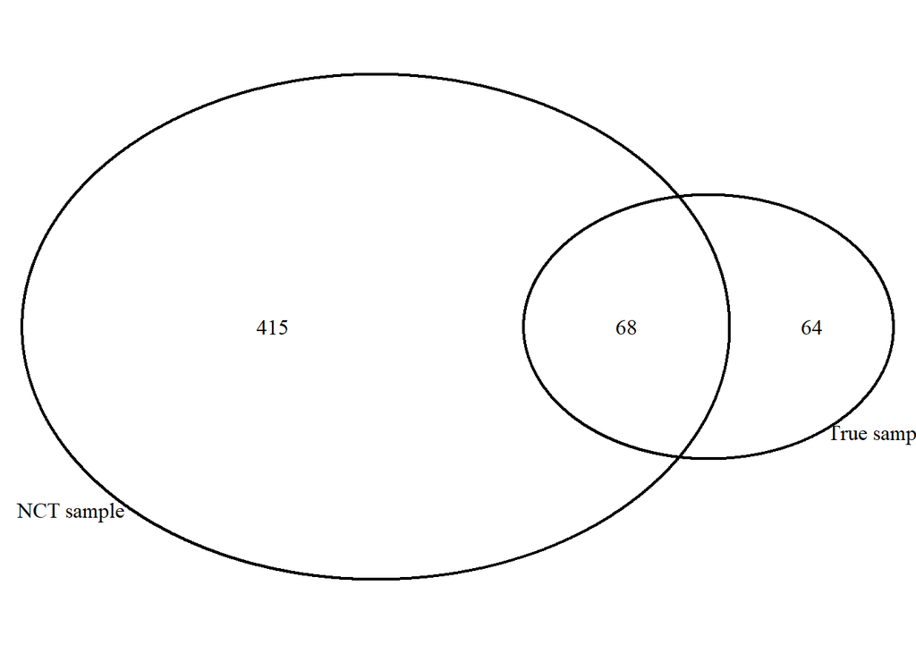

```r
PlotVenn2Sets(rownames(otu_table(p.true.RmLowAbun.RmHighPrev)), rownames(otu_table(physeq.nct.RmLowAbun.RmHighPrev)), "True samples", "NCT sample")
```

#### 2.6.4.2 Low prevalence taxas in NCTs

For those taxa whose prevalence are low in NCT samples, we apply Binomial test per-condition, per-batch to determine if they are contaminants or not. This is filter 2-5 according to Nejman et al.

We need metadata information to proceed

##### 2.6.4.2.1 Preparation

The samples in each condition each batch must contain both true sample and NCTs in order to apply Binomial test. Thus, we first check how many of them are valid

```r
metadata <- meta(p.comb.RmLowAbun) %>% mutate(
  sample_type = ifelse(grepl("paraffin", tolower(sample_side), fixed = TRUE),"paraffin",
                                                     ifelse(grepl("buffer", tolower(sample_side), fixed = TRUE),"buffer",
                                                    ifelse(grepl("pcr", tolower(sample_side), fixed = TRUE),"pcr_ctrl",
                                                           ifelse(grepl("sequence", tolower(sample_side), fixed = TRUE),"sequence","true_sample")))),
  uniqueID = id)




dna_nct <- metadata %>% filter(sample_type == "buffer") %>% pull(DNAex_round) %>% unique()
dna_true <- metadata %>% filter(sample_type == "true_sample") %>% pull(DNAex_round) %>% unique()
pcr_nct <- metadata %>% filter(sample_type == "pcr_ctrl") %>% pull(PCR_round) %>% unique()
pcr_true <- metadata %>% filter(sample_type == "true_sample") %>% pull(PCR_round) %>% unique()
seq_nct <- metadata %>% filter(sample_type == "sequence") %>% pull(Seq_round) %>% unique()
seq_true <- metadata %>% filter(sample_type == "true_sample") %>% pull(Seq_round) %>% unique()

tibble(
  "DNAex batch" = ifelse(identical(dna_nct, dna_true) == TRUE, "Valid", paste( length(which(is.na(match(dna_true, dna_nct)))), "batch(es) are different")),
  "PCR batch" = ifelse(identical(pcr_nct, pcr_true) == TRUE, "Valid", paste( length(which(is.na(match(pcr_true, pcr_nct)))), "batch(es) are different")),
  "Sequencing batch" = ifelse(identical(seq_nct, seq_true) == TRUE, "Valid", paste( length(which(is.na(match(seq_true, seq_nct)))), "batch(es) are different"))
) %>%
  kable (caption=paste("Valid batches"), booktabs =TRUE) %>%
  kable_classic(full_width = F, html_font = "Cambria") %>%
  kable_styling(bootstrap_options = c("striped", "hover", "condensed", "responsive"))
```

Valid batches

| DNAex batch | PCR batch | Sequencing batch |
| --- | --- | --- |
| Valid | Valid | Valid |

##### 2.6.4.2.2 Binominal test batch- and condition-wise

Column uniqueID is needed for the function.

```r
sample_data(p.true.RmLowAbun.RmHighPrev)$uniqueID <- sample_data(p.true.RmLowAbun.RmHighPrev)$id
sample_data(physeq.nct.RmLowAbun.RmHighPrev)$uniqueID <- sample_data(physeq.nct.RmLowAbun.RmHighPrev)$id


# sample_data(p.true.RmLowAbun.RmHighPrev) <- meta(p.true.RmLowAbun.RmHighPrev) %>% select(-Seq_round)
# sample_data(physeq.nct.RmLowAbun.RmHighPrev) <- meta(physeq.nct.RmLowAbun.RmHighPrev) %>% select(-Seq_round)
```

For each condition each batch, we apply Binomial test on each taxa whose prevalence are low in NCT samples, to determine if they are contaminants and then remove them from true samples.

```r
p <- p.true.RmLowAbun.RmHighPrev
p.true.RmLowAbun.RmHLPrev <- Wrapper_Nejman1(p.true.RmLowAbun.RmHighPrev, physeq.nct.RmLowAbun.RmHighPrev, metadata, x = p)

#remove samples without bacteria
p.true.RmLowAbun.RmHLPrev <- subset_samples(physeq = p.true.RmLowAbun.RmHLPrev, sample_sums(p.true.RmLowAbun.RmHLPrev) > 0)


saveRDS(p.true.RmLowAbun.RmHLPrev, "physeqs/p.nejman_8nct.rds")


cont_taxid <- cont_nej_low(p.true.RmLowAbun.RmHighPrev, physeq.nct.RmLowAbun.RmHighPrev, metadata,x = p)


keep.nct.taxa <- setdiff(taxa_names(physeq.nct.RmLowAbun.RmHighPrev), cont_taxid)
physeq.nct.RmLowAbun.RmHighPrev.lowcont <- prune_taxa(keep.nct.taxa, physeq.nct.RmLowAbun.RmHighPrev)
```

All taxa in NCTs were defined as contaminants.

#### 2.6.4.3 Microbial composition

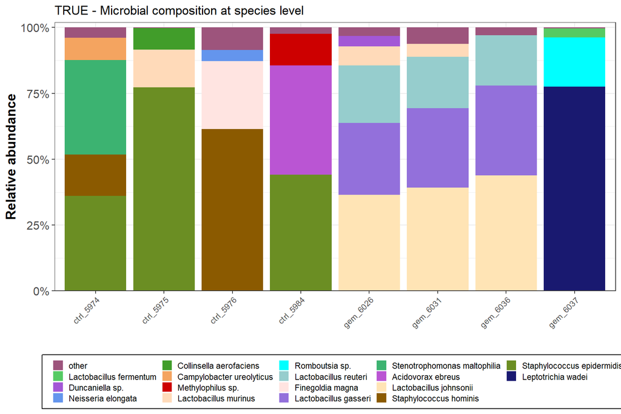

```r
p.prop <- microbiome::transform(p.true.RmLowAbun.RmHLPrev, "compositional")
df.fam.melt <- psmelt(p.prop) %>%
  mutate(species.v2 = if_else(
    Abundance < 0.03, "other", species
   ),
   species.v2 = factor(species.v2, levels=rev(unique(species.v2)))
  )

rm(p.prop)


#microbial composition at species level
ggplot(df.fam.melt, aes(x=id, y=Abundance, fill=species.v2)) +
  geom_bar(stat="identity") +
  scale_y_continuous(labels = scales::percent, expand = c(0, 0), limits = c(0, 1.02)) +
  scale_fill_manual(values = cols) +
  xlab ("") +
  ylab("Relative abundance") +
  theme_bw() +
  # facet_wrap(vars(Treatment), scales = "free_y") +
  ggtitle("TRUE - Microbial composition at species level")+
  # facet_wrap(~sample_side, scales = "free")+
  theme( axis.text.x = element_text(angle = 45,hjust=1),
        axis.text.y = element_text (size=12),
        axis.title = element_text(size=14, face="bold"))+
  theme(legend.position = "bottom",
        legend.title = element_blank(),
        legend.background = element_rect(linetype="solid", colour ="black"),
        legend.key.size = unit(4,"mm"))
```

# 3. Comparison Decontamination approaches

## 3.1 Preparation

```r
dc_low <- readRDS("physeqs/p.decontam.rds")
dc_high <- readRDS("physeqs/p.decontam_default_nct_high_score.rds")
dc_low_8nct <- readRDS("physeqs/p.decontam_8nct.rds")
scrub_low <- readRDS("physeqs/p.scrub.rds")
scrub_high <- readRDS("physeqs/p.scrub_nct_high_score.rds")
scrub_low_8nct <- readRDS("physeqs/p.scrub_8nct.rds")
nej <- readRDS("physeqs/p.nejman.rds")
nej_8nct <- readRDS("physeqs/p.nejman_8nct.rds")
```

## 3.2. Overview

```r
ov <- tibble(
  Decontamination = c("Decontam Low Scores 4xNCT", "Decontam Low Scores 8xNCT", "Decontam High Scores 4xNCT", "SCRuB Low Scores 4xNCT", "SCRuB Low Scores 8xNCT", "SCRuB High Scores4xNCT", "Nejman 4xNCT", "Nejman 8xNCT"),
  "Count of TRUE Taxa" = c(ntaxa(dc_low), ntaxa(dc_low_8nct), ntaxa(dc_high), ntaxa(scrub_low), ntaxa(scrub_low_8nct), ntaxa(scrub_high), ntaxa(nej), ntaxa(nej_8nct)),
  "Count of COntaminants" = c(ntaxa(p.true.RmLowAbun) - ntaxa(dc_low), ntaxa(p.true.RmLowAbun) - ntaxa(dc_low_8nct),  ntaxa(p.true.RmLowAbun) - ntaxa(dc_high), ntaxa(p.true.RmLowAbun) - ntaxa(scrub_low), ntaxa(p.true.RmLowAbun) - ntaxa(scrub_low_8nct), ntaxa(p.true.RmLowAbun) - ntaxa(scrub_high), ntaxa(p.true.RmLowAbun) - ntaxa(nej),  ntaxa(p.true.RmLowAbun) - ntaxa(nej_8nct)),
  "Mean read Count" = c(mean(sample_sums(dc_low)), mean(sample_sums(dc_low_8nct)), mean(sample_sums(dc_high)), mean(sample_sums(scrub_low)), mean(sample_sums(scrub_low_8nct)), mean(sample_sums(scrub_high)), mean(sample_sums(nej)),  mean(sample_sums(nej_8nct))),
   "Min read Count" = c(min(sample_sums(dc_low)), min(sample_sums(dc_low_8nct)), min(sample_sums(dc_high)), min(sample_sums(scrub_low)), min(sample_sums(scrub_low_8nct)), min(sample_sums(scrub_high)), min(sample_sums(nej)), min(sample_sums(nej_8nct))),
  "Max read Count" = c(max(sample_sums(dc_low)), max(sample_sums(dc_low_8nct)), max(sample_sums(dc_high)), max(sample_sums(scrub_low)), max(sample_sums(scrub_low_8nct)), max(sample_sums(scrub_high)), max(sample_sums(nej)), max(sample_sums(nej_8nct)))
)

ov %>% write.xlsx("tables/overview_decontamination_approaches_8NCT.xlsx")

ov %>% kable (caption=paste("Overview Decontamination approaches"), booktabs =TRUE) %>%
  kable_classic(full_width = F, html_font = "Cambria") %>%
  kable_styling(bootstrap_options = c("striped", "hover", "condensed", "responsive"))
```

Overview Decontamination approaches

| Decontamination | Count of TRUE Taxa | Count of COntaminants | Mean read Count | Min read Count | Max read Count |
| --- | --- | --- | --- | --- | --- |
| Decontam Low Scores 4xNCT | 97 | 69 | 61708.50 | 29235 | 116994 |
| Decontam Low Scores 8xNCT | 91 | 75 | 61105.25 | 30516 | 117276 |
| Decontam High Scores 4xNCT | 121 | 45 | 48442.50 | 8277 | 116500 |
| SCRuB Low Scores 4xNCT | 93 | 73 | 59518.12 | 27450 | 114924 |
| SCRuB Low Scores 8xNCT | 96 | 70 | 58483.00 | 25855 | 114945 |
| SCRuB High Scores4xNCT | 124 | 42 | 94504.88 | 74777 | 120050 |
| Nejman 4xNCT | 75 | 91 | 30397.62 | 2316 | 92766 |
| Nejman 8xNCT | 68 | 98 | 43605.62 | 2374 | 116141 |

## 3.2 Overlap

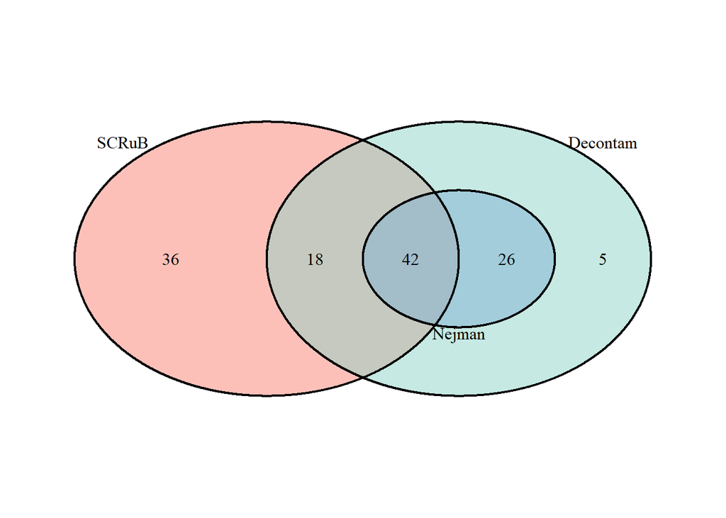

```r
da_venn <- venn.diagram(
  x = list(taxa_names(dc_low_8nct) %>% unique(),
              taxa_names(scrub_low_8nct) %>% unique(),
              taxa_names(nej_8nct) %>% unique()),
  category.names = c("Decontam" , "SCRuB", "Nejman"),
  filename = NULL,
  fill = c("#8DD3C7", "#FB8072", "#80B1D3"),
  margin = 0.1)

grid::grid.newpage()
grid::grid.draw(da_venn)
```

## 3.3 Comparison to known contamination

[Salter et al.](https://pubmed.ncbi.nlm.nih.gov/25387460/) documented common contaminants from the laboratory environment. [Eisenhofer et al.](https://pubmed.ncbi.nlm.nih.gov/30497919/) defined RIDE Guidelines that are minimum quality criteria regarding the handling low-biomass samples and the contamination. Both published a list of genera which were common contaminants.

In the list of Eisenhofer et al. were the Salter contaminants included. However, only genera which were found in at least 2 publication were implmented in the Eisenhofer list. To this end, there are still genera in the Salter list, which are not implemented in Eisenhofers list.

### 3.3.1 Preparation

```r
con.list <- read.xlsx("tables/published_contaminants.xlsx")
# con.list.s <- con.list %>% filter(pub == "Salter")
# con.list.e <- con.list %>% filter(pub == "Eisenhofer")
# setdiff(con.list.e$genus, con.list.s$genus)

con.unique <- con.list %>% pull(genus) %>% unique()
dc_8nct_genus <- tax_tibble(dc_low_8nct) %>% pull(genus) %>% unique()
scrub_8nct_genus <- tax_tibble(scrub_low_8nct) %>% pull(genus) %>% unique()
nej_8nct_genus <- tax_tibble(nej_8nct) %>% pull(genus) %>% unique()
```

### 3.3.2 Overlap With contamination list

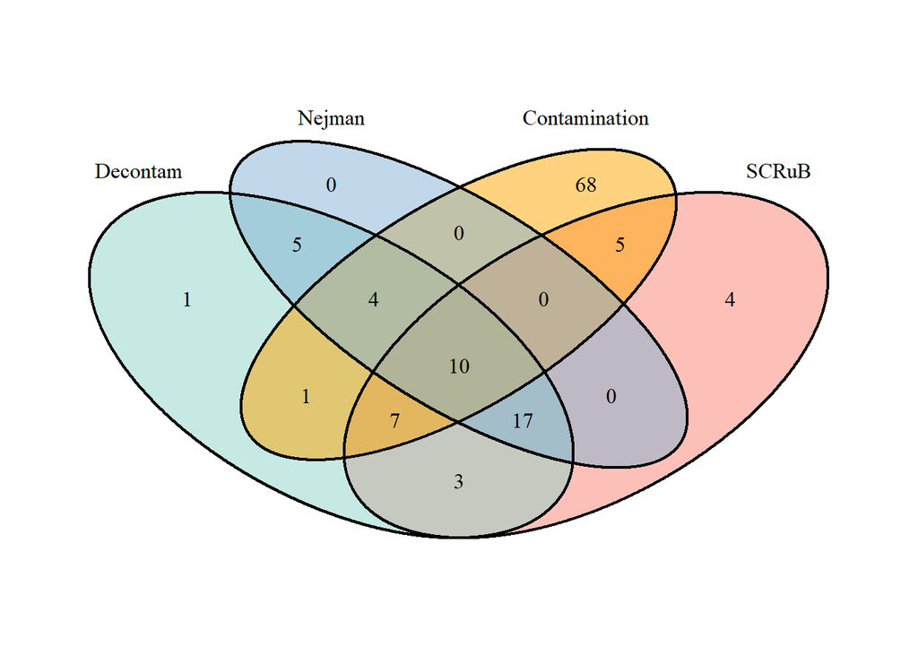

```r
da_venn <- venn.diagram(
  x = list(dc_8nct_genus,
              scrub_8nct_genus,
              nej_8nct_genus,
           con.unique),
  category.names = c("Decontam" , "SCRuB", "Nejman", "Contamination"),
  filename = NULL,
  fill = c("#8DD3C7", "#FB8072", "#80B1D3", "orange"),
  margin = 0.1)

grid::grid.newpage()
grid::grid.draw(da_venn)
```

```r
all.genus <-  unique(c(con.unique, dc_8nct_genus, scrub_8nct_genus, nej_8nct_genus))

gen_overlap <- tibble(
  Genera = all.genus,
  Contamination = if_else(is.na(match(all.genus, con.unique)) == FALSE, "X", "-"),
  Decontam= if_else(is.na(match(all.genus, dc_8nct_genus)) == FALSE, "X", "-"),
  SCRuB= if_else(is.na(match(all.genus, scrub_8nct_genus)) == FALSE, "X", "-"),
  Nejman= if_else(is.na(match(all.genus, nej_8nct_genus)) == FALSE, "X", "-"),
) %>%
  arrange(Genera)

gen_overlap %>% write.xlsx("tables/overlap_contaminants_genus.xlsx")

kable (gen_overlap, caption=paste("Contaminants Overlap of Genera"), booktabs =TRUE) %>%
  kable_classic(full_width = F, html_font = "Cambria") %>%
  kable_styling(bootstrap_options = c("striped", "hover", "condensed", "responsive")) %>%
  scroll_box(width = "90%", height = "600px")
```

Contaminants Overlap of Genera

| Genera | Contamination | Decontam | SCRuB | Nejman |
| --- | --- | --- | --- | --- |
| Abiotrophia | X | - | - | - |
| Achromobacter | X | - | - | - |
| Acidaminococcus | X | - | - | - |
| Acidovorax | X | X | X | X |
| Acinetobacter | X | X | X | X |
| Actinobacillus | X | - | - | - |
| Actinomyces | X | X | X | - |
| Adlercreutzia | - | X | - | X |
| Aeromicrobium | X | - | - | - |
| Aeromonas | X | - | - | - |
| Afipia | X | - | - | - |
| Alistipes | - | X | X | X |
| Aminobacter | X | - | - | - |
| Anaerococcus | X | - | - | - |
| Arthrobacter | X | - | - | - |
| Atopobium | X | X | X | - |
| Bacillus | X | - | - | - |
| Bacteroides | - | X | X | X |
| Bordetella | X | - | - | - |
| Brachybacterium | X | - | - | - |
| Bradyrhizobium | X | - | - | - |
| Brevibacillus | X | - | - | - |
| Brevundimonas | X | - | - | - |
| Burkholderia | X | - | - | - |
| Campylobacter | - | X | X | X |
| Capnocytophaga | X | - | - | - |
| Chryseobacterium | X | - | X | - |
| Cloacibacterium | - | X | X | - |
| Clostridium | X | X | X | X |
| Collinsella | - | X | X | X |

[output cut: 95 more lines]

```r
freq_overlap <- tibble(
  Approach = c("Decontam", "SCRuB", "Nejman"),
  "Overlap [%]" = c(round(length(which(!is.na(match(dc_8nct_genus, con.unique))))/length(dc_8nct_genus)*100, digits = 2),
              round(length(which(!is.na(match(scrub_8nct_genus, con.unique))))/length(scrub_8nct_genus)*100, digits = 2),
              round(length(which(!is.na(match(nej_8nct_genus, con.unique))))/length(nej_8nct_genus)*100, digits = 2)
              )
)

freq_overlap %>% write.xlsx("tables/overlap_contaminants_frequencies.xlsx")

kable (freq_overlap, caption=paste("Contaminants Overlap Frequencies"), booktabs =TRUE) %>%
  kable_classic(full_width = F, html_font = "Cambria") %>%
  kable_styling(bootstrap_options = c("striped", "hover", "condensed", "responsive"))
```

Contaminants Overlap Frequencies

| Approach | Overlap [%] |
| --- | --- |
| Decontam | 45.83 |
| SCRuB | 47.83 |
| Nejman | 38.89 |

# 4. Normailization

## 4.1 Decontam

```r
seed <- 711

sample.size <- min(sample_sums(dc_low_8nct))
dc.rar <- rarefy_even_depth(physeq = dc_low_8nct, sample.size = sample.size, rngseed = seed)
```

## 4.2 SCRuB

```r
seed <- 711

sample.size <- min(sample_sums(scrub_low_8nct))
scrub.rar <- rarefy_even_depth(physeq = scrub_low_8nct, sample.size = sample.size, rngseed = seed)
```

## 4.3 Nejman

```r
seed <- 711

sample.size <- min(sample_sums(nej_8nct))
nej.rar <- rarefy_even_depth(physeq = nej_8nct, sample.size = sample.size, rngseed = seed)
```

## 4.3 Without decontamination

```r
seed <- 711

sample.size <- min(sample_sums(p.true.RmLowAbun))
wo_d.rar <- rarefy_even_depth(physeq = p.true.RmLowAbun, sample.size = sample.size, rngseed = seed)
```

# 5. Analysis

## 5.1 Alpha diversity

### 5.1.1 Decontam

```r
rich = estimate_richness(dc.rar)
rich_meta <- merge(sample_data(dc.rar),rich, by="row.names")


#Shapiro-Wilk
sh.ob <- rich_meta %>% group_by(Treatment) %>% shapiro_test(Observed)
sh.sh <- rich_meta %>% group_by(Treatment) %>% shapiro_test(Shannon)
sh.in <- rich_meta %>% group_by(Treatment) %>% shapiro_test(InvSimpson)

# sh.ob
# sh.sh
# sh.in

# #Levene Test
l.ob <- rich_meta %>% levene_test(Observed ~ Treatment)
l.sh <- rich_meta %>% levene_test(Shannon ~ Treatment)
l.in <- rich_meta %>% levene_test(InvSimpson ~ Treatment)

# l.ob
# l.sh
# l.in


# # stat-test
ob <- rich_meta %>% t_test(Observed ~ Treatment) %>% adjust_pvalue(method = "BH") %>%  add_significance("p.adj") %>% add_xy_position()
sh <- rich_meta %>% t_test(Shannon ~ Treatment) %>% adjust_pvalue(method = "BH") %>%  add_significance("p.adj") %>% add_xy_position()
iv <- rich_meta %>% t_test(InvSimpson ~ Treatment) %>% adjust_pvalue(method = "BH") %>%  add_significance("p.adj") %>% add_xy_position()

ob
```

```
# A tibble: 1 × 14
  .y.      group1 group2    n1    n2 statistic    df     p p.adj p.adj.signif
  <chr>    <chr>  <chr>  <int> <int>     <dbl> <dbl> <dbl> <dbl> <chr>
1 Observed ctrl   Gem        4     4         0  4.81     1     1 ns
# ℹ 4 more variables: y.position <dbl>, groups <named list>, xmin <dbl>,
#   xmax <dbl>
```

```r
sh
```

```
# A tibble: 1 × 14
  .y.     group1 group2    n1    n2 statistic    df      p  p.adj p.adj.signif
  <chr>   <chr>  <chr>  <int> <int>     <dbl> <dbl>  <dbl>  <dbl> <chr>
1 Shannon ctrl   Gem        4     4      3.01  5.49 0.0265 0.0265 *
# ℹ 4 more variables: y.position <dbl>, groups <named list>, xmin <dbl>,
#   xmax <dbl>
```

```r
iv
```

```
# A tibble: 1 × 14
  .y.       group1 group2    n1    n2 statistic    df      p  p.adj p.adj.signif
  <chr>     <chr>  <chr>  <int> <int>     <dbl> <dbl>  <dbl>  <dbl> <chr>
1 InvSimps… ctrl   Gem        4     4      2.19  3.77 0.0976 0.0976 ns
# ℹ 4 more variables: y.position <dbl>, groups <named list>, xmin <dbl>,
#   xmax <dbl>
```

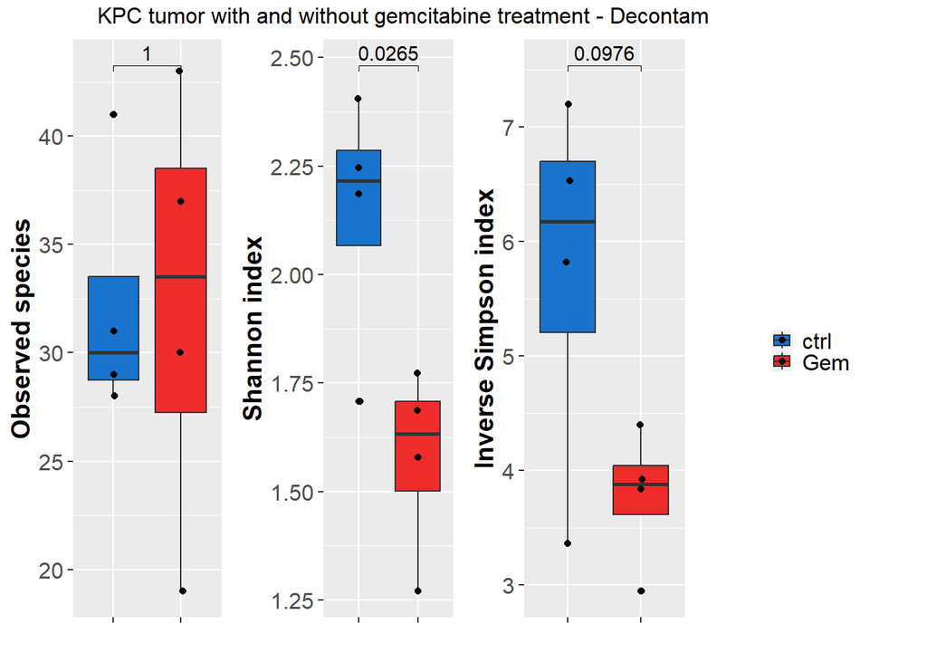

```r
group.colors <- c(ctrl = "dodgerblue3", Gem = "firebrick2")
my.labels <- c("Ctrl", "Gem")

#Observed species
p1 <- ggplot (rich_meta, aes (x=Treatment, y=Observed, fill=Treatment))+
  geom_boxplot()+
  geom_point (position=position_jitterdodge( jitter.width = 0.05))+
  theme_gray() +
  xlab("")+
  ylab("Observed species")+
  # facet_grid(.~tp)+
  scale_x_discrete(labels= my.labels)+
  scale_fill_manual(values=group.colors, labels = c("KPC tumor with and without gemcitabine treatment"))+
  # ggtitle("KPC tumor vs. Healthy pancreas - Observed species") +
  theme(axis.text.y = element_text (size=12),
        axis.title = element_text(size=14, face="bold"))+
  theme(legend.position = "none",
        # legend.background = element_rect(size=0.25, linetype="solid", colour ="black"),
        legend.key.size = unit(4,"mm"),
        axis.text.x = element_blank(),
        plot.title = element_text(size = 14))+
   stat_pvalue_manual(ob, label = "p.adj", inherit.aes = FALSE, tip.length = 0.01)

#Shannon index
p2 <- ggplot (rich_meta, aes (x=Treatment, y=Shannon, fill=Treatment))+
  geom_boxplot()+
  geom_point (position=position_jitterdodge( jitter.width = 0.05))+
  theme_gray() +
  xlab("")+
  ylab("Shannon index")+
  # facet_grid(.~tp)+
  scale_x_discrete(labels= my.labels)+
  scale_fill_manual(values=group.colors, labels = c("KPC tumor with and without gemcitabine treatment"))+
  # ggtitle("KPC tumor vs. Healthy pancreas - Shannon index") +
  theme(axis.text.y = element_text (size=12),
        axis.title = element_text(size=14, face="bold"))+
  theme(legend.position = "none",
        # legend.background = element_rect(size=0.25, linetype="solid", colour ="black"),
        legend.key.size = unit(4,"mm"),
        axis.text.x = element_blank(),
        plot.title = element_text(size = 14))+
   stat_pvalue_manual(sh, label = "p.adj", inherit.aes = FALSE, tip.length = 0.01)

#InvSimpson index
p3 <- ggplot (rich_meta, aes (x=Treatment, y=InvSimpson, fill=Treatment))+
  geom_boxplot()+
  geom_point (position=position_jitterdodge( jitter.width = 0.05))+
  theme_gray() +
  xlab("")+
  ylab("Inverse Simpson index")+
  # facet_grid(.~tp)+
  scale_x_discrete(labels= my.labels)+
  scale_fill_manual(values=group.colors)+
  # ggtitle("KPC tumor vs. Healthy pancreas - Inverse Simpson index") +
  theme(axis.text.y = element_text (size=12),
        axis.title = element_text(size=14, face="bold"))+
  theme(legend.text = element_text(size = 12),
        legend.title = element_blank(),
        # legend.background = element_rect(size=0.25, linetype="solid", colour ="black"),
        legend.key.size = unit(4,"mm"),
        axis.text.x = element_blank(),
        plot.title = element_text(size = 14))+
   stat_pvalue_manual(iv, label = "p.adj", inherit.aes = FALSE, tip.length = 0.01)

legend <- get_legend(p3)
p3 <- p3 + theme(legend.position="none")
grid.arrange(p1, p2, p3, legend, ncol = 4, top = textGrob("KPC tumor with and without gemcitabine treatment - Decontam",  x = 0, hjust = -0.16))
```

### 5.1.2 SCRuB

```r
rich = estimate_richness(scrub.rar)
rich_meta <- merge(sample_data(scrub.rar),rich, by="row.names")


#Shapiro-Wilk
sh.ob <- rich_meta %>% group_by(Treatment) %>% shapiro_test(Observed)
sh.sh <- rich_meta %>% group_by(Treatment) %>% shapiro_test(Shannon)
sh.in <- rich_meta %>% group_by(Treatment) %>% shapiro_test(InvSimpson)

# sh.ob
# sh.sh
# sh.in

# #Levene Test
l.ob <- rich_meta %>% levene_test(Observed ~ Treatment)
l.sh <- rich_meta %>% levene_test(Shannon ~ Treatment)
l.in <- rich_meta %>% levene_test(InvSimpson ~ Treatment)

# l.ob
# l.sh
# l.in


# # stat-test
ob <- rich_meta %>% t_test(Observed ~ Treatment) %>% adjust_pvalue(method = "BH") %>%  add_significance("p.adj") %>% add_xy_position()
sh <- rich_meta %>% t_test(Shannon ~ Treatment) %>% adjust_pvalue(method = "BH") %>%  add_significance("p.adj") %>% add_xy_position()
iv <- rich_meta %>% wilcox_test(InvSimpson ~ Treatment) %>% adjust_pvalue(method = "BH") %>%  add_significance("p.adj") %>% add_xy_position()

ob
```

```
# A tibble: 1 × 14
  .y.      group1 group2    n1    n2 statistic    df     p p.adj p.adj.signif
  <chr>    <chr>  <chr>  <int> <int>     <dbl> <dbl> <dbl> <dbl> <chr>
1 Observed ctrl   Gem        4     4     0.516  5.33 0.626 0.626 ns
# ℹ 4 more variables: y.position <dbl>, groups <named list>, xmin <dbl>,
#   xmax <dbl>
```

```r
sh
```

```
# A tibble: 1 × 14
  .y.     group1 group2    n1    n2 statistic    df     p p.adj p.adj.signif
  <chr>   <chr>  <chr>  <int> <int>     <dbl> <dbl> <dbl> <dbl> <chr>
1 Shannon ctrl   Gem        4     4      2.04  4.31 0.106 0.106 ns
# ℹ 4 more variables: y.position <dbl>, groups <named list>, xmin <dbl>,
#   xmax <dbl>
```

```r
iv
```

```
# A tibble: 1 × 13
  .y.    group1 group2    n1    n2 statistic     p p.adj p.adj.signif y.position
  <chr>  <chr>  <chr>  <int> <int>     <dbl> <dbl> <dbl> <chr>             <dbl>
1 InvSi… ctrl   Gem        4     4        13   0.2   0.2 ns                 9.35
# ℹ 3 more variables: groups <named list>, xmin <dbl>, xmax <dbl>
```

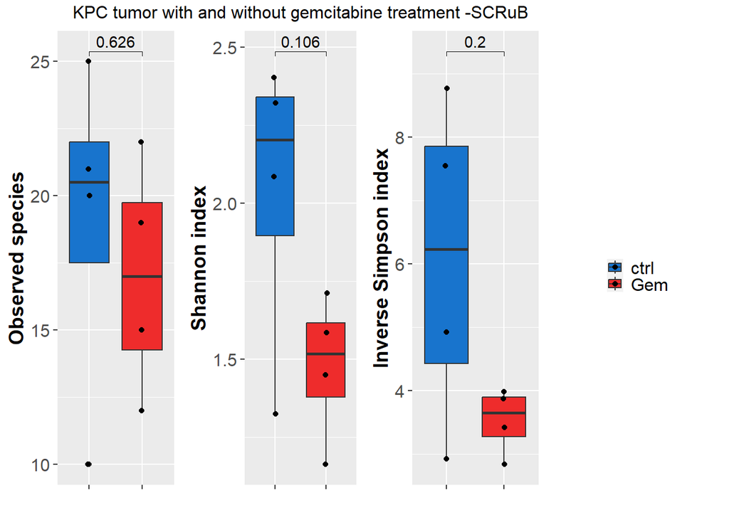

```r
group.colors <- c(ctrl = "dodgerblue3", Gem = "firebrick2")
my.labels <- c("Ctrl", "Gem")

#Observed species
p1 <- ggplot (rich_meta, aes (x=Treatment, y=Observed, fill=Treatment))+
  geom_boxplot()+
  geom_point (position=position_jitterdodge( jitter.width = 0.05))+
  theme_gray() +
  xlab("")+
  ylab("Observed species")+
  # facet_grid(.~tp)+
  scale_x_discrete(labels= my.labels)+
  scale_fill_manual(values=group.colors, labels = c("KPC tumor with and without gemcitabine treatment"))+
  # ggtitle("KPC tumor vs. Healthy pancreas - Observed species") +
  theme(axis.text.y = element_text (size=12),
        axis.title = element_text(size=14, face="bold"))+
  theme(legend.position = "none",
        # legend.background = element_rect(size=0.25, linetype="solid", colour ="black"),
        legend.key.size = unit(4,"mm"),
        axis.text.x = element_blank(),
        plot.title = element_text(size = 14))+
   stat_pvalue_manual(ob, label = "p.adj", inherit.aes = FALSE, tip.length = 0.01)

#Shannon index
p2 <- ggplot (rich_meta, aes (x=Treatment, y=Shannon, fill=Treatment))+
  geom_boxplot()+
  geom_point (position=position_jitterdodge( jitter.width = 0.05))+
  theme_gray() +
  xlab("")+
  ylab("Shannon index")+
  # facet_grid(.~tp)+
  scale_x_discrete(labels= my.labels)+
  scale_fill_manual(values=group.colors, labels = c("KPC tumor with and without gemcitabine treatment"))+
  # ggtitle("KPC tumor vs. Healthy pancreas - Shannon index") +
  theme(axis.text.y = element_text (size=12),
        axis.title = element_text(size=14, face="bold"))+
  theme(legend.position = "none",
        # legend.background = element_rect(size=0.25, linetype="solid", colour ="black"),
        legend.key.size = unit(4,"mm"),
        axis.text.x = element_blank(),
        plot.title = element_text(size = 14))+
   stat_pvalue_manual(sh, label = "p.adj", inherit.aes = FALSE, tip.length = 0.01)

#InvSimpson index
p3 <- ggplot (rich_meta, aes (x=Treatment, y=InvSimpson, fill=Treatment))+
  geom_boxplot()+
  geom_point (position=position_jitterdodge( jitter.width = 0.05))+
  theme_gray() +
  xlab("")+
  ylab("Inverse Simpson index")+
  # facet_grid(.~tp)+
  scale_x_discrete(labels= my.labels)+
  scale_fill_manual(values=group.colors)+
  # ggtitle("KPC tumor vs. Healthy pancreas - Inverse Simpson index") +
  theme(axis.text.y = element_text (size=12),
        axis.title = element_text(size=14, face="bold"))+
  theme(legend.text = element_text(size = 12),
        legend.title = element_blank(),
        # legend.background = element_rect(size=0.25, linetype="solid", colour ="black"),
        legend.key.size = unit(4,"mm"),
        axis.text.x = element_blank(),
        plot.title = element_text(size = 14))+
   stat_pvalue_manual(iv, label = "p.adj", inherit.aes = FALSE, tip.length = 0.01)

legend <- get_legend(p3)
p3 <- p3 + theme(legend.position="none")
grid.arrange(p1, p2, p3, legend, ncol = 4, top = textGrob("KPC tumor with and without gemcitabine treatment -SCRuB",  x = 0, hjust = -0.16))
```

### 5.1.3 Nejman

[figure not shown]

```r
rich = estimate_richness(nej.rar)
rich_meta <- merge(sample_data(nej.rar),rich, by="row.names")


#Shapiro-Wilk
sh.ob <- rich_meta %>% group_by(Treatment) %>% shapiro_test(Observed)
sh.sh <- rich_meta %>% group_by(Treatment) %>% shapiro_test(Shannon)
sh.in <- rich_meta %>% group_by(Treatment) %>% shapiro_test(InvSimpson)

# sh.ob
# sh.sh
# sh.in

# #Levene Test
l.ob <- rich_meta %>% levene_test(Observed ~ Treatment)
l.sh <- rich_meta %>% levene_test(Shannon ~ Treatment)
l.in <- rich_meta %>% levene_test(InvSimpson ~ Treatment)

# l.ob
# l.sh
# l.in


# # stat-test
ob <- rich_meta %>% t_test(Observed ~ Treatment) %>% adjust_pvalue(method = "BH") %>%  add_significance("p.adj") %>% add_xy_position()
sh <- rich_meta %>% t_test(Shannon ~ Treatment) %>% adjust_pvalue(method = "BH") %>%  add_significance("p.adj") %>% add_xy_position()
iv <- rich_meta %>% t_test(InvSimpson ~ Treatment) %>% adjust_pvalue(method = "BH") %>%  add_significance("p.adj") %>% add_xy_position()

# ob
# sh
# iv

group.colors <- c(ctrl = "dodgerblue3", Gem = "firebrick2")
my.labels <- c("Ctrl", "Gem")

#Observed species
p1 <- ggplot (rich_meta, aes (x=Treatment, y=Observed, fill=Treatment))+
  geom_boxplot()+
  geom_point (position=position_jitterdodge( jitter.width = 0.05))+
  theme_gray() +
  xlab("")+
  ylab("Observed species")+
  # facet_grid(.~tp)+
  scale_x_discrete(labels= my.labels)+
  scale_fill_manual(values=group.colors, labels = c("KPC tumor with and without gemcitabine treatment"))+
  # ggtitle("KPC tumor vs. Healthy pancreas - Observed species") +
  theme(axis.text.y = element_text (size=12),
        axis.title = element_text(size=14, face="bold"))+
  theme(legend.position = "none",
        # legend.background = element_rect(size=0.25, linetype="solid", colour ="black"),
        legend.key.size = unit(4,"mm"),
        axis.text.x = element_blank(),
        plot.title = element_text(size = 14))+
   stat_pvalue_manual(ob, label = "p.adj", inherit.aes = FALSE, tip.length = 0.01)

#Shannon index
p2 <- ggplot (rich_meta, aes (x=Treatment, y=Shannon, fill=Treatment))+
  geom_boxplot()+
  geom_point (position=position_jitterdodge( jitter.width = 0.05))+
  theme_gray() +
  xlab("")+
  ylab("Shannon index")+
  # facet_grid(.~tp)+
  scale_x_discrete(labels= my.labels)+
  scale_fill_manual(values=group.colors, labels = c("KPC tumor with and without gemcitabine treatment"))+
  # ggtitle("KPC tumor vs. Healthy pancreas - Shannon index") +
  theme(axis.text.y = element_text (size=12),
        axis.title = element_text(size=14, face="bold"))+
  theme(legend.position = "none",
        # legend.background = element_rect(size=0.25, linetype="solid", colour ="black"),
        legend.key.size = unit(4,"mm"),
        axis.text.x = element_blank(),
        plot.title = element_text(size = 14))+
   stat_pvalue_manual(sh, label = "p.adj", inherit.aes = FALSE, tip.length = 0.01)

#InvSimpson index
p3 <- ggplot (rich_meta, aes (x=Treatment, y=InvSimpson, fill=Treatment))+
  geom_boxplot()+
  geom_point (position=position_jitterdodge( jitter.width = 0.05))+
  theme_gray() +
  xlab("")+
  ylab("Inverse Simpson index")+
  # facet_grid(.~tp)+
  scale_x_discrete(labels= my.labels)+
  scale_fill_manual(values=group.colors)+
  # ggtitle("KPC tumor vs. Healthy pancreas - Inverse Simpson index") +
  theme(axis.text.y = element_text (size=12),
        axis.title = element_text(size=14, face="bold"))+
  theme(legend.text = element_text(size = 12),
        legend.title = element_blank(),
        # legend.background = element_rect(size=0.25, linetype="solid", colour ="black"),
        legend.key.size = unit(4,"mm"),
        axis.text.x = element_blank(),
        plot.title = element_text(size = 14))+
   stat_pvalue_manual(iv, label = "p.adj", inherit.aes = FALSE, tip.length = 0.01)

legend <- get_legend(p3)
p3 <- p3 + theme(legend.position="none")
grid.arrange(p1, p2, p3, legend, ncol = 4, top = textGrob("KPC tumor with and without gemcitabine treatment - Alpha diversity metrics - Decontam",  x = 0, hjust = -0.16))
```

## 5.2 Beta-diversity

### 5.2.1 Decontam

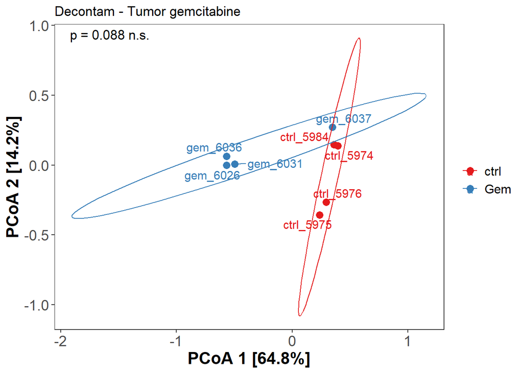

```r
bray_dist = phyloseq::distance(dc.rar, method="bray")
ordination = ordinate(dc.rar, method="PCoA", distance=bray_dist)

pcoa1 <- paste("PCoA 1 [", round(ordination[[3]]$Relative_eig[1], digits = 3)*100, "%]", sep = "")
pcoa2 <- paste("PCoA 2 [", round(ordination[[3]]$Relative_eig[2], digits = 3)*100, "%]", sep = "")

p.adonis <- adonis2(bray_dist ~ sample_data(dc.rar)$Treatment)
p <- case_when(
  p.adonis$`Pr(>F)`[1] > 0.05 ~ paste("p =", p.adonis$`Pr(>F)`[1], "n.s.", sep = " "),
  p.adonis$`Pr(>F)`[1] < 0.05 &  p.adonis$`Pr(>F)`[1] > 0.01 ~ paste("p =", p.adonis$`Pr(>F)`[1], "*", sep = " "),
  p.adonis$`Pr(>F)`[1] <= 0.01 & p.adonis$`Pr(>F)`[1] > 0.001  ~ paste("p =", p.adonis$`Pr(>F)`[1], "**", sep = " "),
  p.adonis$`Pr(>F)`[1] <= 0.001 ~ paste("p =",p.adonis$`Pr(>F)`[1], "***", sep = " "),
)

annotations <- data.frame(
        xpos = c(-Inf),
        ypos =  c(Inf),
        annotateText = p,
        hjustvar = c(-0.2) ,
        vjustvar = c(1.5))

plot_ordination(dc.rar, ordination, color = "Treatment") +
  geom_point(aes(colour = Treatment), size = 3) +
  geom_text_repel(aes(label = id), size = 4) +
  theme(aspect.ratio=1) +
  theme_bw()+
  scale_color_brewer(palette = "Set1")+
  stat_ellipse() +
  xlab(pcoa1)+
  ylab(pcoa2)+
  theme(panel.grid =  element_blank())+
  ggtitle("Decontam - Tumor gemcitabine") +
  theme (axis.text=element_text(size=14),
         axis.title=element_text(size=16,face="bold"),
        legend.text = element_text(size = 12),
        legend.title = element_blank())+
  geom_text(data=annotations,aes(x=xpos,y=ypos,hjust=hjustvar,vjust=vjustvar,label=annotateText), size = 4.5, inherit.aes = FALSE)
```

### 5.2.2 SCRuB

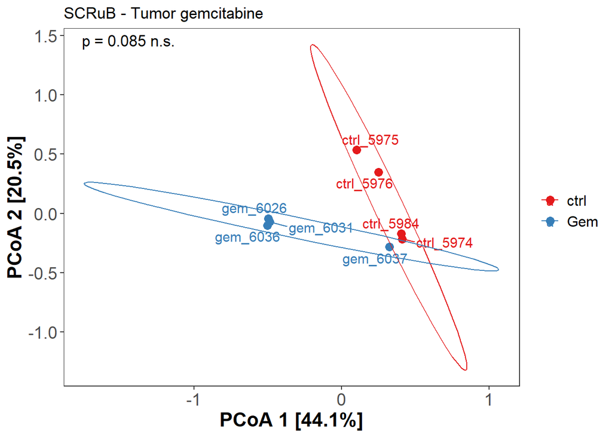

```r
bray_dist = phyloseq::distance(scrub.rar, method="bray")
ordination = ordinate(scrub.rar, method="PCoA", distance=bray_dist)

pcoa1 <- paste("PCoA 1 [", round(ordination[[3]]$Relative_eig[1], digits = 3)*100, "%]", sep = "")
pcoa2 <- paste("PCoA 2 [", round(ordination[[3]]$Relative_eig[2], digits = 3)*100, "%]", sep = "")

p.adonis <- adonis2(bray_dist ~ sample_data(scrub.rar)$Treatment)
p <- case_when(
  p.adonis$`Pr(>F)`[1] > 0.05 ~ paste("p =", p.adonis$`Pr(>F)`[1], "n.s.", sep = " "),
  p.adonis$`Pr(>F)`[1] < 0.05 &  p.adonis$`Pr(>F)`[1] > 0.01 ~ paste("p =", p.adonis$`Pr(>F)`[1], "*", sep = " "),
  p.adonis$`Pr(>F)`[1] <= 0.01 & p.adonis$`Pr(>F)`[1] > 0.001  ~ paste("p =", p.adonis$`Pr(>F)`[1], "**", sep = " "),
  p.adonis$`Pr(>F)`[1] <= 0.001 ~ paste("p =",p.adonis$`Pr(>F)`[1], "***", sep = " "),
)

annotations <- data.frame(
        xpos = c(-Inf),
        ypos =  c(Inf),
        annotateText = p,
        hjustvar = c(-0.2) ,
        vjustvar = c(1.5))

plot_ordination(scrub.rar, ordination, color = "Treatment") +
  geom_point(aes(colour = Treatment), size = 3) +
  geom_text_repel(aes(label = id), size = 4) +
  theme(aspect.ratio=1) +
  theme_bw()+
  scale_color_brewer(palette = "Set1")+
  stat_ellipse() +
  xlab(pcoa1)+
  ylab(pcoa2)+
  theme(panel.grid =  element_blank())+
  ggtitle("SCRuB - Tumor gemcitabine") +
  theme (axis.text=element_text(size=14),
         axis.title=element_text(size=16,face="bold"),
        legend.text = element_text(size = 12),
        legend.title = element_blank())+
  geom_text(data=annotations,aes(x=xpos,y=ypos,hjust=hjustvar,vjust=vjustvar,label=annotateText), size = 4.5, inherit.aes = FALSE)
```

### 5.2.3 Nejman

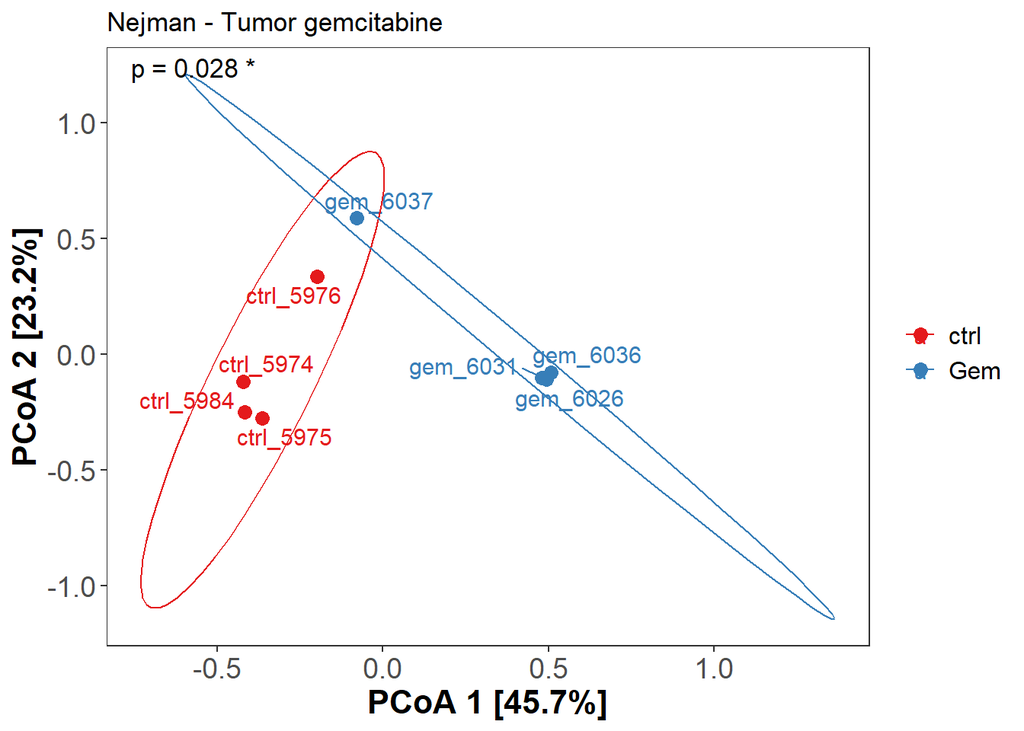

```r
bray_dist = phyloseq::distance(nej.rar, method="bray")
ordination = ordinate(nej.rar, method="PCoA", distance=bray_dist)

pcoa1 <- paste("PCoA 1 [", round(ordination[[3]]$Relative_eig[1], digits = 3)*100, "%]", sep = "")
pcoa2 <- paste("PCoA 2 [", round(ordination[[3]]$Relative_eig[2], digits = 3)*100, "%]", sep = "")

p.adonis <- adonis2(bray_dist ~ sample_data(nej.rar)$Treatment)
p <- case_when(
  p.adonis$`Pr(>F)`[1] > 0.05 ~ paste("p =", p.adonis$`Pr(>F)`[1], "n.s.", sep = " "),
  p.adonis$`Pr(>F)`[1] < 0.05 &  p.adonis$`Pr(>F)`[1] > 0.01 ~ paste("p =", p.adonis$`Pr(>F)`[1], "*", sep = " "),
  p.adonis$`Pr(>F)`[1] <= 0.01 & p.adonis$`Pr(>F)`[1] > 0.001  ~ paste("p =", p.adonis$`Pr(>F)`[1], "**", sep = " "),
  p.adonis$`Pr(>F)`[1] <= 0.001 ~ paste("p =",p.adonis$`Pr(>F)`[1], "***", sep = " "),
)

annotations <- data.frame(
        xpos = c(-Inf),
        ypos =  c(Inf),
        annotateText = p,
        hjustvar = c(-0.2) ,
        vjustvar = c(1.5))

plot_ordination(nej.rar, ordination, color = "Treatment") +
  geom_point(aes(colour = Treatment), size = 3) +
  geom_text_repel(aes(label = id), size = 4) +
  theme(aspect.ratio=1) +
  theme_bw()+
  scale_color_brewer(palette = "Set1")+
  stat_ellipse() +
  xlab(pcoa1)+
  ylab(pcoa2)+
  theme(panel.grid =  element_blank())+
  ggtitle("Nejman - Tumor gemcitabine") +
  theme (axis.text=element_text(size=14),
         axis.title=element_text(size=16,face="bold"),
        legend.text = element_text(size = 12),
        legend.title = element_blank())+
  geom_text(data=annotations,aes(x=xpos,y=ypos,hjust=hjustvar,vjust=vjustvar,label=annotateText), size = 4.5, inherit.aes = FALSE)
```

### 5.2.3 Without Decontamination

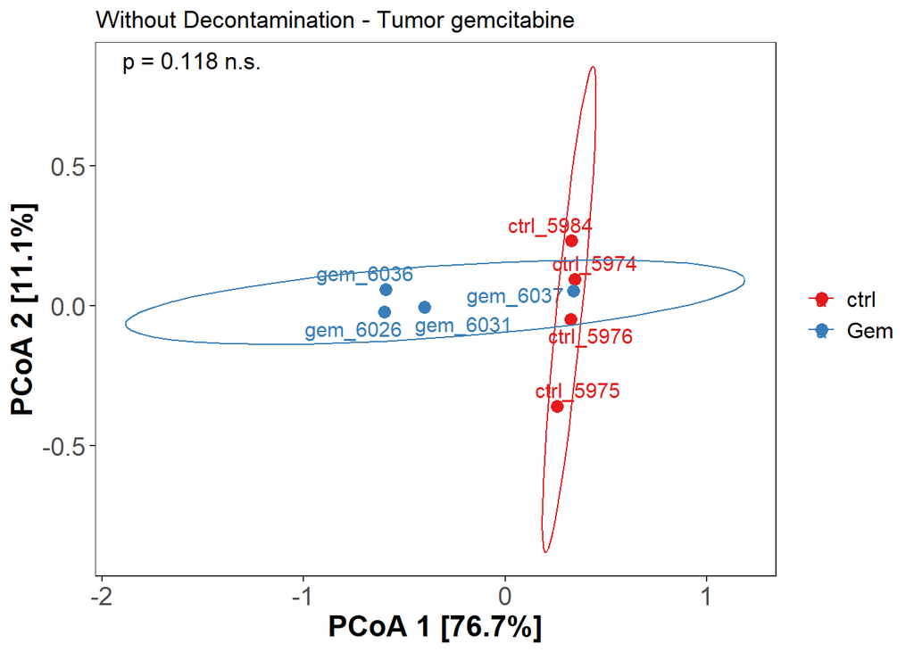

```r
bray_dist = phyloseq::distance(wo_d.rar, method="bray")
ordination = ordinate(wo_d.rar, method="PCoA", distance=bray_dist)

pcoa1 <- paste("PCoA 1 [", round(ordination[[3]]$Relative_eig[1], digits = 3)*100, "%]", sep = "")
pcoa2 <- paste("PCoA 2 [", round(ordination[[3]]$Relative_eig[2], digits = 3)*100, "%]", sep = "")

p.adonis <- adonis2(bray_dist ~ sample_data(wo_d.rar)$Treatment)
p <- case_when(
  p.adonis$`Pr(>F)`[1] > 0.05 ~ paste("p =", p.adonis$`Pr(>F)`[1], "n.s.", sep = " "),
  p.adonis$`Pr(>F)`[1] < 0.05 &  p.adonis$`Pr(>F)`[1] > 0.01 ~ paste("p =", p.adonis$`Pr(>F)`[1], "*", sep = " "),
  p.adonis$`Pr(>F)`[1] <= 0.01 & p.adonis$`Pr(>F)`[1] > 0.001  ~ paste("p =", p.adonis$`Pr(>F)`[1], "**", sep = " "),
  p.adonis$`Pr(>F)`[1] <= 0.001 ~ paste("p =",p.adonis$`Pr(>F)`[1], "***", sep = " "),
)

annotations <- data.frame(
        xpos = c(-Inf),
        ypos =  c(Inf),
        annotateText = p,
        hjustvar = c(-0.2) ,
        vjustvar = c(1.5))

plot_ordination(wo_d.rar, ordination, color = "Treatment") +
  geom_point(aes(colour = Treatment), size = 3) +
  geom_text_repel(aes(label = id), size = 4) +
  theme(aspect.ratio=1) +
  theme_bw()+
  scale_color_brewer(palette = "Set1")+
  stat_ellipse() +
  xlab(pcoa1)+
  ylab(pcoa2)+
  theme(panel.grid =  element_blank())+
  ggtitle("Without Decontamination - Tumor gemcitabine") +
  theme (axis.text=element_text(size=14),
         axis.title=element_text(size=16,face="bold"),
        legend.text = element_text(size = 12),
        legend.title = element_blank())+
  geom_text(data=annotations,aes(x=xpos,y=ypos,hjust=hjustvar,vjust=vjustvar,label=annotateText), size = 4.5, inherit.aes = FALSE)
```

# 6. Technical controls

In the following we like to perform plausibility tests of the decontamination process. For this we want to check the relative abundances of different species in negative controls and true samples.

Species:

1. Prevotella melaninogenica
2. Sphingomonas sp.
3. Schaalia odontolytica
4. Lactobacillus johnsonii
5. Clostridium isatidis
6. Sphingomonas panacis
7. Sphingomonas alpina

For this we take the phyloseq before decontamination and compare it to the NCT phyloseq

```r
true_prop <- microbiome::transform(p.true.RmLowAbun, "compositional")
true.melt <- psmelt(true_prop)

# true.melt %>% filter(genus == "Sphingomonas")
# dc_low_8nct_prop <- microbiome::transform(dc_low_8nct, "compositional")
# dc_low_8nct.melt <- psmelt(dc_low_8nct_prop)
# dc_low_8nct.melt %>% filter(genus == "Sphingomonas")

nct_prop <- microbiome::transform(physeq.nct.RmLowAbun, "compositional")
nct.melt <- psmelt(nct_prop)

taxa_of_interest <- true.melt %>%
  filter(species == "Prevotella melaninogenica" | species == "Sphingomonas sp." | species == "Schaalia odontolytica" | species == "Lactobacillus johnsonii" | species == "Clostridium isatidis" | species == "Sphingomonas panacis" | species == "Sphingomonas alpina") %>%
  pull(OTU) %>%
  unique()

taxa_names_interest <- true.melt %>% filter(OTU %in% taxa_of_interest) %>% select(species, OTU) %>% unique()


prev_true <- as.data.frame(prevalence(true_prop, detection  = 0, sort = TRUE, count = FALSE)) %>%
  mutate(taxid = rownames(.),
         type = "true") %>%
  filter(taxid %in% taxa_of_interest) %>%
  rename(prevalence = `prevalence(true_prop, detection = 0, sort = TRUE, count = FALSE)`) %>%
  as_tibble()

abu_true <- as.data.frame(abundances(true_prop)) %>%
  mutate(taxid = rownames(.))%>%
  filter(taxid %in% taxa_of_interest) %>%
  select(-taxid) %>%
  t()%>%
  as.data.frame() %>%
  mutate(type = "true")

prev_nct <- as.data.frame(prevalence(nct_prop, detection  = 0, sort = TRUE, count = FALSE)) %>%
  mutate(taxid = rownames(.),
         type = "nct") %>%
  filter(taxid %in% taxa_of_interest) %>%
  rename(prevalence = `prevalence(nct_prop, detection = 0, sort = TRUE, count = FALSE)`) %>%
  as_tibble()

abu_nct <- as.data.frame(abundances(nct_prop)) %>%
  mutate(taxid = rownames(.))%>%
  filter(taxid %in% taxa_of_interest) %>%
  select(-taxid) %>%
  t() %>%
  as.data.frame() %>%
  mutate(type = "nct")

bind_rows(prev_true, prev_nct)
```

```
# A tibble: 12 × 3
   prevalence taxid   type
        <dbl> <chr>   <chr>
 1      1     1523415 true
 2      1     1408186 true
 3      1     653931  true
 4      1     28132   true
 5      1     1660    true
 6      0.75  1560345 true
 7      0.25  182773  true
 8      1     1660    nct
 9      0.875 653931  nct
10      0.875 28132   nct
11      0.75  1560345 nct
12      0.75  1523415 nct
```

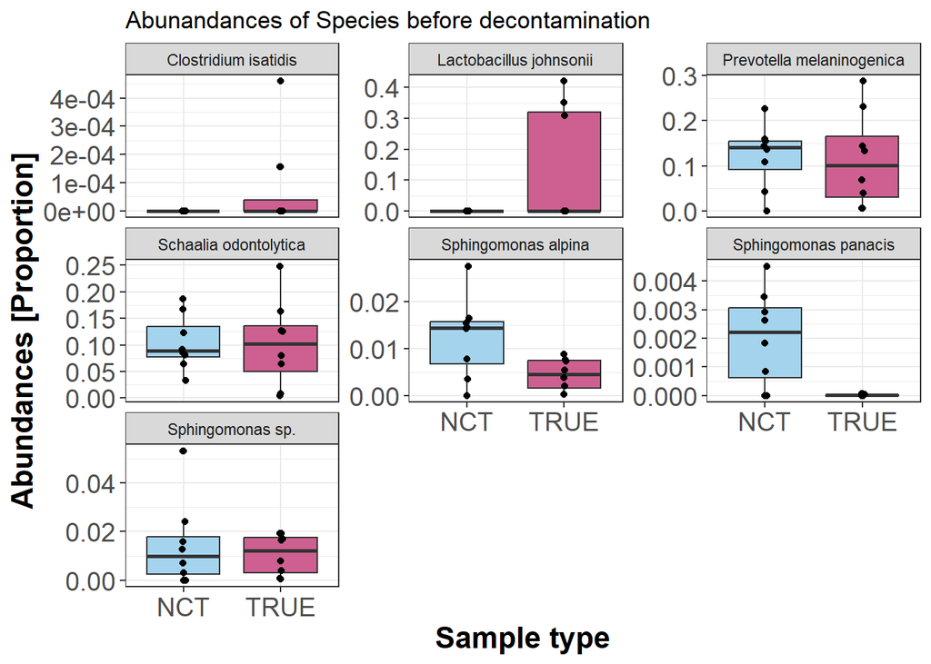

```r
bind_rows(abu_true, abu_nct) %>%
    pivot_longer(-type, names_to = "OTU", values_to = "abundance") %>%
  mutate(abundance = if_else(is.na(abundance), 0, abundance)) %>%
  left_join(taxa_names_interest, by = "OTU") %>%
  ggplot(aes(x=type, y=abundance, fill= type)) +
  # geom_violin()+
  geom_boxplot()+
  geom_point (position=position_jitterdodge( jitter.width = 0.05))+
  theme_bw() +
  facet_wrap(.~species, scales = "free_y")+
  ggtitle ("Abunandances of Species before decontamination") +
  scale_x_discrete(labels= c("NCT", "TRUE"))+
  xlab("Sample type")+
  ylab("Abundances [Proportion]")+
   scale_fill_manual(values = c("lightskyblue2", "hotpink3"), labels= c("NCT", "TRUE"))+
theme (axis.text=element_text(size=14),
         axis.title=element_text(size=16,face="bold"),
         legend.position =  "none",
         legend.title = element_blank(),
         legend.background = element_rect(linetype="solid", colour ="black"))
```